# **Introduction to Econometrics Using R**

Messaoud Zouikri, CNRS, EconomiX

20/05/2021

# What is *R* ?

is a programming language mainly used for statistical computing, data analysis and graphics. it is a free, open source language developed as a [GNU project](https://www.gnu.org/home.en.html) and so licensed under the General Public Licence [(GPL)](https://www.gnu.org/licenses/licenses.en.html).

# Downloading and Installing R and RStudio

can be downloaded from the Comprehensive R Archive Network [(CRAN)](https://cran.r-project.org/). It is available for multiplatform operating systems (Linux, Windows and Mac OS).

can be downloaded and installed for free for a personal use from the RStudio [web page](https://rstudio.com/products/rstudio/download/). RStudio is a Graphical User Interface (GUI) as well as an environment for R simplifying its use for statistical programming and data analysis in a user-friendly way.

## R Interfaces

The simple *R* version is composed of a window console (see the part 1 in the graphic below) where the *R* code is written and then executed by just typing <**Enter**> or <**Ctrl+Enter**> (in Windows system) and <**Cmd+Enter**> (in Mac Os). The output is displayed in the same window (see window 1 in the graph below), if the task performed is the display of statistics, and in a new window (see part 2, graph below) if the output is a graphic, the help or a list of objects.

To save the history of the executed code that can be re-used in the further sessions, the entire work can be written in a script. The latter is saved with the extension **.R** and executed into the R console using the command **source**(“*ScriptName*.R”) or in a terminal, using the command **Rscript** followed by the *ScriptName*.R

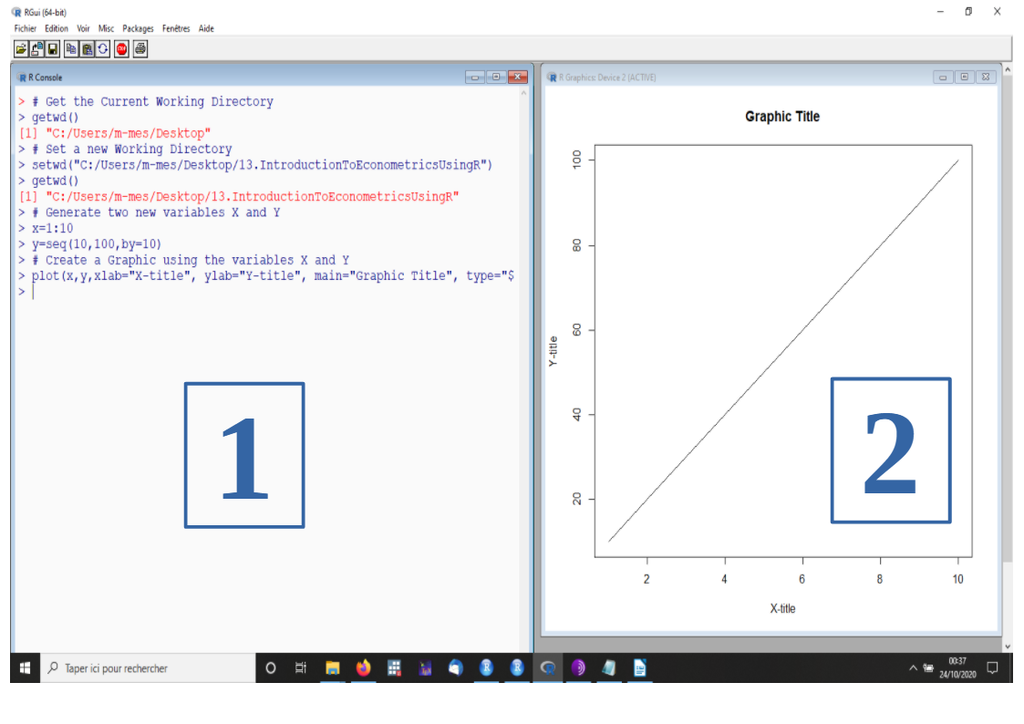

**RStudio** is a GUI that allows simplicity and interactivity by adding many helpful functionality to the use of *R*. Four windows form the Rstudio interface. The first one is dedicated to writing the *R* code script (1). The second, is a console (2) where results of the executed code are displayed. It is equivalent to that of the *R* simple interface without a GUI. The console is usually used to execute temporary code that don’t need to be saved for further use. RStudio interface contains also a window that shows the imported data files or data created by the user (3) and lastly, a window displaying the contents of the current working directory, the generated plots, and other useful information (4).

[figure not shown]

# R environment

The *R* environment is made up of native packages that contain many functions each of them running a special task.

## The *R* Base Package

The *R* Base is the basic version that we obtain when installing *R* for the first time. We can obtain the list of the default installed packages with the *R* Base Package on the [CRAN](https://stat.ethz.ch/R-manual/R-devel/library/base/html/00Index.html) site.

To get the number of the installed packages, we use the **nrow()** function:

```r
options(repos="https://cran.rstudio.com")
nrow(installed.packages())
```

```
## [1] 362
```

## R Packages extension

When dealing with more advanced statistical analysis or econometric modeling, the *R* base packages may not be sufficient to handle all the required models by the user. In this case, we can use the external packages developed by the large *R* Developers Community. A package can be installed using the command **install.packages**(“*PackageName*”) and then loaded in memory using **library**(“*PackageName*”).

The number of packages offered by CRAN is continuously increasing. The list of the current packages available can be viewed at the [CRAN](https://cran.r-project.org/web/packages/available_packages_by_name.html).

Likewise, we can use the **nrow()** *R* command to calculate their number:

```r
nrow(available.packages())
```

```
## [1] 18618
```

We can also check on the CRAN site the available packages by [topic](https://cran.r-project.org/web/views/) to focus on those we are interested in, such as [Econometrics](https://cran.r-project.org/web/views/Econometrics.html), [Finance](https://cran.r-project.org/web/views/Finance.html), [Time Series](https://cran.r-project.org/web/views/TimeSeries.html), [Graphics](https://cran.r-project.org/web/views/Graphics.html), etc.

## *R* Packages for Datascience

The *tidyverse* is a set of packages used to deal with datascience issues in *R* as same as *Pandas* and *Scikit-Learn* libraries for Python language. It has been written initially by [Hadley Wickham](http://hadley.nz/), a statistician, software developer and professor of statistics, currently Chief Scientist at RStudio. The “*tidyverse*” packages work as a unified framework because they share common data representations. This package-parent is designed to make it easy to install and load multiple “*tidyverse*” packages in a single step. The installation of “*tidyverse*” allows the use of eight packages:

**dplyr**, **tidyr**, **tibble**, **forcats**, **readr**, **purrr**, **stringr** and **ggplot2** to achieve different tasks related to data analysis, graphics and statistical modeling (see the figure below).

[figure not shown]

1. **dplyr**: Offers a grammar of data manipulation. It is a fast, consistent tool for working with data frame like objects, both in memory and out of memory.
2. **tidyr**: Is a tool for creating data as dataframe format and tools for working with missing values.
3. **tibble**: Provides tools for formatting data more than the traditional data frame.
4. **forcats**: Contains tools for working with categorical variables (Factors).
5. **readr**: Provides a fast and friendly way to read rectangular data.
6. **purrr**: Is a complete and consistent functional programming toolkit for *R*.
7. **stringr**: Is a simple and consistent wrappers for common string operations.
8. **ggplot2**: Offers very powerful tools for creating elegant data visualizations using the grammar of graphics.

To check the content of “*tidyverse*” package we first install and load it in memory.

```r
# Installing and loading "tidyverse".

# install.packages("tidyverse")  # Remove the "#" symbol to enable the installation.

# Loading "tidyverse" package into active memory.

library("tidyverse")
```

To get a description of *Tidyverse* package:

```r
# Getting information on the "tidyverse" package.

library(help="tidyverse")
```

Once *tidyverse* package is installed and loaded, we can check its content using:

```r
tidyverse_packages()
```

```
##  [1] "broom"         "cli"           "crayon"        "dbplyr"
##  [5] "dplyr"         "dtplyr"        "forcats"       "googledrive"
##  [9] "googlesheets4" "ggplot2"       "haven"         "hms"
## [13] "httr"          "jsonlite"      "lubridate"     "magrittr"
## [17] "modelr"        "pillar"        "purrr"         "readr"
## [21] "readxl"        "reprex"        "rlang"         "rstudioapi"
## [25] "rvest"         "stringr"       "tibble"        "tidyr"
## [29] "xml2"          "tidyverse"
```

## *R* files system

The *R* script is written in a simple text document and saved with **.R** extension, while *R* database files are saved with **.RData** extension.

# Getting help on a *R* function

To get help on a specific *R* function we can use both the following commands:

**help** **(** *FunctionName* **)**

**?** *FunctionName*.

For instance, to get help on the **mean** function, we can type:

```r
help(mean)
```

```
## starting httpd help server ... done
```

Or

```r
? mean
```

The help gives a description of the function, its usage, list a few main references and offers some practical examples for its use.

# Creating, modifying and deleting data

First of all, *R* can be used as a simple calculator:

```r
2*2
```

```
## [1] 4
```

```r
100/5
```

```
## [1] 20
```

```r
2^10
```

```
## [1] 1024
```

We can then store the result of a calculation using the famous *R* assignement symbol **<-** in an object which can be used later.

```r
a <- 2^10
```

And then we can apply on the object any function such as **log** (*x*), **abs** (*x*), **sqrt** (*x*), etc.

```r
log(a)
```

```
## [1] 6.931472
```

We can create data from scratch, either by combining variables created separately as *R* objects or in one step. The structure of the created objects may have different types in *R*. An object may be, *character*, *numeric* (real or decimal), *integer*, *logical* or *complex*.

To begin, we create some variables from online real data on covid19, available on the internet on [Worldometers](https://www.worldometers.info/coronavirus/) web site.

```r
# Creating variables.

countries <- c("France", "Germany", "Spain", "Italy")
CovidCases <- c(1502763, 580415, 1331756, 759829)
CovidDeaths <- c(38289,10904,36495,39412)
```

In the case we do not explicitly indicate the variable nature, *R* recognises it anyway by attributing the right type. In the example above, the variable (object) ‘countries’ is assigned by *R* as a *character* type, because it is put within brackets. As the other two variables contain numbers, they are thus recognised as *numeric*.

To combine the three variables in one single database, we can use the **dataframe** structure. In short, a *dataframe* corresponds to a sheet structured as rows and columns, where each column is a variable, each row is an observation, and each cell contains a single value. The first row contains usually the columns’ name.

By assigning *covidata* as a name to the data resulting from the combination of *countries*, *CovidCases* and *CovidDeaths* objects, we get a new dataset structured as a dataframe format using the function **data.frame** ().

```r
# Creating 'covidata' set as a data frame.

covidata <- data.frame(countries,CovidCases,CovidDeaths)
```

*Covidata* is now the new dataset containing the three objects (Countries, CovidCases, CovidDeaths) structured like a sheet by rows and columns.

To save a copy of it in the current directory, we can use the **save** () function.

```r
# Saving a copyt of 'covidata' in the local working directory.

save(covidata,file="covidata.RData")
```

As described in the help, the saved objects can be read back from the file at a later date by using the function **load** () or **attach** (or data in some cases).

To delete data files or directories definitely, we use **unlink** (*DataName*) function as follows:

```r
# Deleting the "covidata" file from the local directory.

unlink("covidata.RData")
```

We notice that at this stage, notwithstanding we have deleted the saved file, the data opened in memory (*covidata*) still exists and so, we can continue to use it in the current session. Data in memory can be removed using the **rm** (*DataName*) function or by choosing not to save the file, when closing the *R* programs (session).

To check the type of covidata file, we can use the **class** (*DataName*) command:

```r
# Checking the class category of 'covidata'.

class(covidata)
```

```
## [1] "data.frame"
```

To show its structure, we use the **str** (*DataName*) function:

```r
# Looking at the structure of 'covidata'.

str(covidata)
```

```
## 'data.frame':    4 obs. of  3 variables:
##  $ countries  : chr  "France" "Germany" "Spain" "Italy"
##  $ CovidCases : num  1502763 580415 1331756 759829
##  $ CovidDeaths: num  38289 10904 36495 39412
```

To visualize the whole dataset, we can just type its name in the console:

```r
# Showing the 'covidata' content.

covidata
```

| countries | CovidCases | CovidDeaths |
| --- | --- | --- |
| France | 1502763 | 38289 |
| Germany | 580415 | 10904 |
| Spain | 1331756 | 36495 |
| Italy | 759829 | 39412 |

This way of doing things is not convenient when the database is very large containing many rows and columns. In this case, it is recommended to just check the beginning and the end of the file, using either functions:

**head** (*DataName*)

or

**tail** (*DataName*).

To visualise data in an external sheet, we can use the **View** (*DataName*) command (with V in capital letters):

```r
# Visualising data in a sheet.

View (covidata)
```

To show all names of data columns, we can use the **names()** function.

```r
# Showing the names of all the columns (variables) of "covidata" that is three in this case.

names(covidata)
```

```
## [1] "countries"   "CovidCases"  "CovidDeaths"
```

# Reading internal data and importing external data files

The basic *R* installation comes with a data package named “*datasets*”. It contains datasets on different topics that can be used to learn *R*. Some of these data, such as *mtcars* and *iris*, are widely used in tutorials and online learning courses.

## Reading internal data

To load in memory the *datasets* package:

```r
# Loading the "datasets" package.

library("datasets")
```

To see the content of the *datasets* package, we can use either:

```r
# Showing the help on "datasets" package.

library(help="datasets")
```

Or

```r
# Showing the list of available internal datasets.

data()
```

To load in memory a particular dataset (mtcars):

```r
# Loading the "mtcars" data.

data(mtcars)
```

To check the structure and content of the *mtcars* dataset, we use some basic functions that we already saw above:

```r
# First, to have more information on the mtcars data columns (variables) we can ask for the help file.

?mtcars
```

```r
# Sructure of mtcars

str(mtcars)
```

```
## 'data.frame':    32 obs. of  11 variables:
##  $ mpg : num  21 21 22.8 21.4 18.7 18.1 14.3 24.4 22.8 19.2 ...
##  $ cyl : num  6 6 4 6 8 6 8 4 4 6 ...
##  $ disp: num  160 160 108 258 360 ...
##  $ hp  : num  110 110 93 110 175 105 245 62 95 123 ...
##  $ drat: num  3.9 3.9 3.85 3.08 3.15 2.76 3.21 3.69 3.92 3.92 ...
##  $ wt  : num  2.62 2.88 2.32 3.21 3.44 ...
##  $ qsec: num  16.5 17 18.6 19.4 17 ...
##  $ vs  : num  0 0 1 1 0 1 0 1 1 1 ...
##  $ am  : num  1 1 1 0 0 0 0 0 0 0 ...
##  $ gear: num  4 4 4 3 3 3 3 4 4 4 ...
##  $ carb: num  4 4 1 1 2 1 4 2 2 4 ...
```

```r
# Show the first 10 rows of the data. The default is 6 rows.

head(mtcars, 10)
```

|  | mpg | cyl | disp | hp | drat | wt | qsec | vs | am | gear | carb |
| --- | --- | --- | --- | --- | --- | --- | --- | --- | --- | --- | --- |
| Mazda RX4 | 21.0 | 6 | 160.0 | 110 | 3.90 | 2.620 | 16.46 | 0 | 1 | 4 | 4 |
| Mazda RX4 Wag | 21.0 | 6 | 160.0 | 110 | 3.90 | 2.875 | 17.02 | 0 | 1 | 4 | 4 |
| Datsun 710 | 22.8 | 4 | 108.0 | 93 | 3.85 | 2.320 | 18.61 | 1 | 1 | 4 | 1 |
| Hornet 4 Drive | 21.4 | 6 | 258.0 | 110 | 3.08 | 3.215 | 19.44 | 1 | 0 | 3 | 1 |
| Hornet Sportabout | 18.7 | 8 | 360.0 | 175 | 3.15 | 3.440 | 17.02 | 0 | 0 | 3 | 2 |
| Valiant | 18.1 | 6 | 225.0 | 105 | 2.76 | 3.460 | 20.22 | 1 | 0 | 3 | 1 |
| Duster 360 | 14.3 | 8 | 360.0 | 245 | 3.21 | 3.570 | 15.84 | 0 | 0 | 3 | 4 |
| Merc 240D | 24.4 | 4 | 146.7 | 62 | 3.69 | 3.190 | 20.00 | 1 | 0 | 4 | 2 |
| Merc 230 | 22.8 | 4 | 140.8 | 95 | 3.92 | 3.150 | 22.90 | 1 | 0 | 4 | 2 |
| Merc 280 | 19.2 | 6 | 167.6 | 123 | 3.92 | 3.440 | 18.30 | 1 | 0 | 4 | 4 |

```r
# Show the last rows of data.

tail(mtcars)
```

|  | mpg | cyl | disp | hp | drat | wt | qsec | vs | am | gear | carb |
| --- | --- | --- | --- | --- | --- | --- | --- | --- | --- | --- | --- |
| Porsche 914-2 | 26.0 | 4 | 120.3 | 91 | 4.43 | 2.140 | 16.7 | 0 | 1 | 5 | 2 |
| Lotus Europa | 30.4 | 4 | 95.1 | 113 | 3.77 | 1.513 | 16.9 | 1 | 1 | 5 | 2 |
| Ford Pantera L | 15.8 | 8 | 351.0 | 264 | 4.22 | 3.170 | 14.5 | 0 | 1 | 5 | 4 |
| Ferrari Dino | 19.7 | 6 | 145.0 | 175 | 3.62 | 2.770 | 15.5 | 0 | 1 | 5 | 6 |
| Maserati Bora | 15.0 | 8 | 301.0 | 335 | 3.54 | 3.570 | 14.6 | 0 | 1 | 5 | 8 |
| Volvo 142E | 21.4 | 4 | 121.0 | 109 | 4.11 | 2.780 | 18.6 | 1 | 1 | 4 | 2 |

```r
# To show how many columns the data contains.

ncol(mtcars)
```

```
## [1] 11
```

```r
# To show the number of rows in the dataset.

nrow(mtcars)
```

```
## [1] 32
```

## Importing external data files

*R* has some functions in the Base package allowing to read external data, mainly, Comma Separated Values (CSV) and Delimited data file (delim). Many functions from other packages can read files in different format such as Excel, SAS, SPSS, Stata, etc. These functions are more suited for advanced use of *R*. We focus in this tutorial on how to read CSV and Excel files.

### Reading (importing) CSV data files

Comma-separated values are data in text format where each value is separated by a comma. Separation or delimitation may be a tabulation or any other delimiter such as a semicolon, etc.

The following *R* function

$\text{read.table(file="DataName", header=TRUE, sep=" ", dec=" ", quote= "\"")}$

can be used to read almost all data formatted as text files and creates as an output a data frame from it.

```r
# Read the "crimes_SC.csv" dataset where every single data is separated by a Semicolon.

crimes1<- read.table(file="crimes_SC.csv", sep=";", header=TRUE, dec=".")
```

```r
# Read the "crimes_C.csv" dataset where data is separated by a Comma.

crimes2<- read.table(file="crimes_C.csv", sep=",", header=TRUE, dec=".")
```

```r
# Read the "crimes_SC.csv" dataset where data is separated by a Tabulation.

crimes3<- read.table(file="crimes_T.csv", sep="\t", header=TRUE, dec=".", quote = "\"")
```

### Reading Excel data files

To read Excel files, we can use one of the many functions available in the *tidyverse* package cited above. Before reading $xls$ or $xlsx$ data, we should first load the “**readxl**” library.

```r
library("readxl")
```

To look at the content and usage of *readxl* package.

```r
 help(package="readxl")
```

Reading crimes.xls data file in *R* using the function **read_xls** contained in *readxl* package and assign the output in *crimes_xls* file.

```r
crimes_xls <- read_xls("crimes.xls", sheet=("data"))
```

# Merging datasets

Merging data sets is a part of data preparation (cleaning) which allows to have a single database for the entire study. The need for merging new data with the existing one may appear during the study process because new questions arise as the study progresses, or that the data collection operation itself takes place in different steps.

The merging of data can be performed in two different ways. Adding new variables (columns) or adding new individuals (rows). The first type is an horizontal merge where new data are joined or combined with the current one. The second type is a vertical stacking where new data are overlaid to increase the rows number. Obviously, a third possibility may exist where a merging operation adds new rows as well as new columns to the existing data.

There are several functions present in the package **dplyr** that perfom the joining of data in a very easy way. To get an idea on how these functions work, we can imagine two data sets *data1* and *data2* and then combining them in different ways using **dplyr** tools.

```r
# Creating the first dataset "data1" as a tibble format.

# This first data file (data1) contains three variables: Animals, their babies, and their nature as wild or domestic.

data1 <-tibble(Animals=c("Cat","Chicken","Dog","Elephant","Giraffe","Gnu","Lion",
                         "Panda","Penguin","Rabbit"),
Baby=c("Kitten","Chick","Puppy","Calf","Calf","Calf","Cub","Cub","Chick","Kitten"),
Nature=c("Domestic","Domestic","Domestic","Wild","Wild","Domestic","Wild","Wild",
         "Wild","Domestic"))
```

```r
# Creating the second data file "data2" as a tibble format.

# The second data file (data2) contains also three variables: Animals, their babies, and a new variable, on the 'weight of babies' at birth measured in a kilogram. We notice that the variable 'Animals' includes now two new animals: 'Turkey' and 'Duck'. Likewise, for their babies and weight at birth.

data2<- tibble(Animals=c("Cat","Chicken","Dog","Elephant","Giraffe","Gnu",
                         "Lion","Panda","Penguin","Rabbit","Turkey","Duck"),
Baby=c("Kitten","Chick","Puppy","Calf","Calf","Calf","Cub","Cub","Chick",
       "Kitten","Poult","Duckling"),
Weight=c(0.08,0.9,0.45,90,99,36,8,0.1,0.32,0.03,0.05,0.05))
```

## I. Data joining

When joining data we can distinct between two types, joins that combine data and those that filter the data.

One of the main issues when joining different data files is the specification of one or more common keys on which basis the merging will be done. *R* can implicitly recognise the key(s) used to merge data by comparing and choosing common columns in the different files as a merge criterion. The option, *by=(“merging_keys”)* can be used in case where a specific key is chosen instead.

**1. Combining joins**

Four type of joins can be identifid from the *dplyr* package: **left_join**, **right_join**, **inner_join** and **full_join**

**left_join**

The *left_join* is the most used operation for data sets combining. This method gives the priority to the data file placed on the left (*data1* in the following code). The output contains all the individuals present in file *data1* and add to it new information from the file *data2* for individuals whose identification keys are common. The symbols’ name given to files according to their position are, $x$ for the left side file and $y$ for the right side one.

```r
data_left<- left_join(data1, data2)
```

**right_join**

The *right_join* does the inverse operation compared to the previous one. The reference file in merge is the one placed on the right (*data2*).

```r
data_right<- right_join(data1, data2)
```

**inner_join**

The *inner_join* operation keeps all the information (columns) for only the common individuals between merging files. It is suited for instance in the case when the requested output is a balanced data between different input files.

```r
data_inner <- inner_join(data1, data2)
```

**full_join**

The *full_join* method as its name suggests produces as output a data file that contains all the data from the different files used in the merge. Rows that are not common, based on key merge, will have their columns marked “NA” (for not available).

```r
data_full <- full_join(data1, data2)
```

**2. Filtering joins**

There are two functions that can be used to merge data while filtering based on the merging key.

**semi_join**

The *semi_join* function selects the observations from *data2* ($y$) that are present in *data1* ($x$), without adding new columns from $y$’s file. In other words, this operation keeps at the end, only the observations of $x$ table that are also present in $y$ table.

```r
data_semi <- semi_join(data1,data2)
```

**anti_join**

The *anti_join* does the opposite of *semi_join*. It keeps only observations of $x$ file that are absent from $y$. In the case where all observations from $x$ are present in the $y$ file, the output turns to be a zero observation as in the case below.

```r
data_anti <- anti_join(data1,data2)
```

## II. Data stacking

Sometimes we need to put together different data files by pooling them in a vertical way, rather than joining them horizontally. One of the well known examples to illustrate this case is the panel data format.

The **bind_row()** function from *dplyr* package can be used to combine files by vertical pooling. The output of *bind_rows()* will contain a column if that column appears in any of files used as inputs. It is very important to notice here that the name of variables (columns) must be the same in all data sets used as inputs. Any variable with a different name will be considered as a new variable in the output.

```r
# The following code read three Excel files (f2010.xls, f2012.xls and f2014.xls) and assign them to three data frames: f2010, f2012 and f2014.

library("readxl")
f2010 <- read_xls("f2010.xls")
f2012 <- read_xls("f2012.xls")
f2014 <- read_xls("f2014.xls")
```

Before pooling the data, it is interesting to explore each file entering in data stacking. We limit ourselves in this example to the first file, but we can run the same code for the rest of files.

```r
# Exploring The f2010 data dimension (how many rows and columns contains this data).

dim(f2010)
```

```
## [1] 107  10
```

```r
# Showing the first ten rows and all columns.

slice(f2010,1:10)
```

| id | country | countrycode | year | corruption | gdp_cap | gdp_emp | GCF | GFCF | population |
| --- | --- | --- | --- | --- | --- | --- | --- | --- | --- |
| 1 | Afghanistan | AFG | 2010 | 2.0 | 1662.804 | NA | NA | NA | 27962207 |
| 2 | Albania | ALB | 2010 | NA | 9374.250 | 15190.00 | NA | NA | 2913021 |
| 3 | Angola | AGO | 2010 | 2.5 | 6492.177 | 3356.00 | 11902637599 | 11902637599 | 21219954 |
| 4 | Arab World | ARB | 2010 | 2.3 | 14453.125 | 15000.99 | NA | NA | 352640325 |
| 5 | Armenia | ARM | 2010 | 3.0 | 6507.914 | 27463.00 | 1848669830 | 1871602088 | 2963496 |
| 6 | Azerbaijan | AZE | 2010 | 2.5 | 15950.257 | 18256.00 | 4943658709 | 4916899851 | 9054332 |
| 7 | Bangladesh | BGD | 2010 | 3.0 | 2451.305 | 3841.00 | 27039344485 | 27039344485 | 151616777 |
| 8 | Benin | BEN | 2010 | 3.5 | 1636.554 | NA | 1086030966 | 982242050 | 9509798 |
| 9 | Bhutan | BTN | 2010 | 4.5 | 6485.588 | NA | 817610366 | 811569440 | 720246 |
| 10 | Bolivia | BOL | 2010 | 3.5 | 5405.748 | 7956.00 | 2064877230 | 2003964750 | 9918245 |

```r
# Examining the content of f2010 data (see the columns name).

str(f2010)
```

```
## tibble [107 x 10] (S3: tbl_df/tbl/data.frame)
##  $ id         : num [1:107] 1 2 3 4 5 6 7 8 9 10 ...
##  $ country    : chr [1:107] "Afghanistan" "Albania" "Angola" "Arab World" ...
##  $ countrycode: chr [1:107] "AFG" "ALB" "AGO" "ARB" ...
##  $ year       : num [1:107] 2010 2010 2010 2010 2010 2010 2010 2010 2010 2010 ...
##  $ corruption : num [1:107] 2 NA 2.5 2.3 3 2.5 3 3.5 4.5 3.5 ...
##  $ gdp_cap    : num [1:107] 1663 9374 6492 14453 6508 ...
##  $ gdp_emp    : num [1:107] NA 15190 3356 15001 27463 ...
##  $ GCF        : num [1:107] NA NA 1.19e+10 NA 1.85e+09 ...
##  $ GFCF       : num [1:107] NA NA 1.19e+10 NA 1.87e+09 ...
##  $ population : num [1:107] 2.80e+07 2.91e+06 2.12e+07 3.53e+08 2.96e+06 ...
```

```r
# pooling together the three files containing the same variables observed for three different years, f2010, f2010, f2014 using blind_rows () function.

library("dplyr")
fpanel <- bind_rows(f2010,f2012,f2014)
```

The output of data pooling remains of dimension 10 because the columns name is the same in the three files, but rows are now equal to 321, as resulting from the combination of 107 times 3.

```r
# Exploring the dimension of the entire data after pooling the three files.

dim(fpanel)
```

```
## [1] 321  10
```

```r
# Showing the first ten rows using the "head()" function instead.

head(fpanel,10)
```

| id | country | countrycode | year | corruption | gdp_cap | gdp_emp | GCF | GFCF | population |
| --- | --- | --- | --- | --- | --- | --- | --- | --- | --- |
| 1 | Afghanistan | AFG | 2010 | 2.0 | 1662.804 | NA | NA | NA | 27962207 |
| 2 | Albania | ALB | 2010 | NA | 9374.250 | 15190.00 | NA | NA | 2913021 |
| 3 | Angola | AGO | 2010 | 2.5 | 6492.177 | 3356.00 | 11902637599 | 11902637599 | 21219954 |
| 4 | Arab World | ARB | 2010 | 2.3 | 14453.125 | 15000.99 | NA | NA | 352640325 |
| 5 | Armenia | ARM | 2010 | 3.0 | 6507.914 | 27463.00 | 1848669830 | 1871602088 | 2963496 |
| 6 | Azerbaijan | AZE | 2010 | 2.5 | 15950.257 | 18256.00 | 4943658709 | 4916899851 | 9054332 |
| 7 | Bangladesh | BGD | 2010 | 3.0 | 2451.305 | 3841.00 | 27039344485 | 27039344485 | 151616777 |
| 8 | Benin | BEN | 2010 | 3.5 | 1636.554 | NA | 1086030966 | 982242050 | 9509798 |
| 9 | Bhutan | BTN | 2010 | 4.5 | 6485.588 | NA | 817610366 | 811569440 | 720246 |
| 10 | Bolivia | BOL | 2010 | 3.5 | 5405.748 | 7956.00 | 2064877230 | 2003964750 | 9918245 |

```r
# Exploring the content of the data which equals now: 10 same columns (or variables) and 321 rows (or observations).

str(fpanel)
```

```
## tibble [321 x 10] (S3: tbl_df/tbl/data.frame)
##  $ id         : num [1:321] 1 2 3 4 5 6 7 8 9 10 ...
##  $ country    : chr [1:321] "Afghanistan" "Albania" "Angola" "Arab World" ...
##  $ countrycode: chr [1:321] "AFG" "ALB" "AGO" "ARB" ...
##  $ year       : num [1:321] 2010 2010 2010 2010 2010 2010 2010 2010 2010 2010 ...
##  $ corruption : num [1:321] 2 NA 2.5 2.3 3 2.5 3 3.5 4.5 3.5 ...
##  $ gdp_cap    : num [1:321] 1663 9374 6492 14453 6508 ...
##  $ gdp_emp    : num [1:321] NA 15190 3356 15001 27463 ...
##  $ GCF        : num [1:321] NA NA 1.19e+10 NA 1.85e+09 ...
##  $ GFCF       : num [1:321] NA NA 1.19e+10 NA 1.87e+09 ...
##  $ population : num [1:321] 2.80e+07 2.91e+06 2.12e+07 3.53e+08 2.96e+06 ...
```

# Computing basic statistics

The general purpose behind descriptive statistics is the exploration of data by computing different measures to know their central tendency, dispersion and distribution, and the links that may exist between variables, before going further in the data analysis and statistical modeling.

When analyzing data, it may be interesting to distinguish between, on the one hand, quantitative and qualitative variables and between univariate and multivariate data analysis, on the other hand. Depending on the nature of variables, several tools can be used to analyse, visualize and model the data.

In the rest of the work, the “crimes” database provided with this tutorial will be used to illustrate the different *R* functions dedicated to statistical analysis.

First, we read the crimes data file from excel format ($xls$) using *read_xls* function.

```r
# Loading "readxl" library in memory.

library("readxl")
```

```r
# Reading "crimes.xls" file using "read_xls" function.

crimes <- read_xls("crimes.xls", sheet="data", col_names=TRUE)
```

## Univariate analysis of quantitative data

The objective of the univariate analysis is the exploration of each variable in the database without making any interaction with other variables.

```r
# The dimension of the crimes data (rows x columns).

dim (crimes)
```

```
## [1] 95 11
```

```r
# Showing the first ten rows of the data using "slice" function from "dpyr" package. The "head(crimes, 10)" function from the R Base package could be also used.

slice(crimes,1:10)
```

| dep_code | dep_name | region_name | gdp_2011 | crimes | poverty_index | population | unemp_rate | big_region | pupils | dep_road |
| --- | --- | --- | --- | --- | --- | --- | --- | --- | --- | --- |
| 1 | Ain | Rhône-Alpes | 193696.09 | 21953 | 19.3950 | 621095 | 7.2 | 5 | 83.96635 | 4456.375 |
| 2 | Aisne | Picardie | 44799.48 | 25201 | 19.1989 | 555941 | 14.1 | 1 | 87.69681 | 5467.876 |
| 3 | Allier | Auvergne | 33428.05 | 11840 | 18.2184 | 353036 | 10.5 | 5 | 72.73962 | 5234.175 |
| 4 | Alpes de Haute-Provence | Provence-Alpes-Côte d'Azur | 140501.83 | 7496 | 19.5314 | 166014 | 12.0 | 5 | 83.21108 | 2566.999 |
| 5 | Hautes-Alpes | Provence-Alpes-Côte d'Azur | 140501.83 | 6016 | 17.6727 | 143962 | 9.2 | 5 | 83.35663 | 1959.463 |
| 6 | Alpes-Maritimes | Provence-Alpes-Côte d'Azur | 140501.83 | 92241 | 20.9041 | 1097701 | 10.6 | 5 | 81.31773 | 2629.492 |
| 7 | Ardèche | Rhône-Alpes | 193696.09 | 10868 | 18.8579 | 327072 | 10.6 | 5 | 84.89890 | 3808.001 |
| 8 | Ardennes | Champagne-Ardenne | 36761.73 | 11040 | 20.2817 | 291472 | 12.2 | 1 | 82.39901 | 3250.001 |
| 9 | Ariège | Midi-Pyrénées | 78465.30 | 5034 | 21.4327 | 157936 | 12.2 | 6 | 76.35827 | 2638.819 |
| 10 | Aube | Champagne-Ardenne | 36761.73 | 13759 | 18.8749 | 312211 | 12.3 | 1 | 80.87145 | 4491.623 |

```r
# Getting the columns names of "crimes" data using the "names()" function.

names(crimes)
```

```
##  [1] "dep_code"      "dep_name"      "region_name"   "gdp_2011"
##  [5] "crimes"        "poverty_index" "population"    "unemp_rate"
##  [9] "big_region"    "pupils"        "dep_road"
```

To get more detailed information about the variables, other than their names, we can use the *str()* function instead.

```r
# Data structure of "crimes" file.

str(crimes)
```

```
## tibble [95 x 11] (S3: tbl_df/tbl/data.frame)
##  $ dep_code     : num [1:95] 1 2 3 4 5 6 7 8 9 10 ...
##  $ dep_name     : chr [1:95] "Ain" "Aisne" "Allier" "Alpes de Haute-Provence" ...
##  $ region_name  : chr [1:95] "Rhône-Alpes" "Picardie" "Auvergne" "Provence-Alpes-Côte d'Azur" ...
##  $ gdp_2011     : num [1:95] 193696 44799 33428 140502 140502 ...
##  $ crimes       : num [1:95] 21953 25201 11840 7496 6016 ...
##  $ poverty_index: num [1:95] 19.4 19.2 18.2 19.5 17.7 ...
##  $ population   : num [1:95] 621095 555941 353036 166014 143962 ...
##  $ unemp_rate   : num [1:95] 7.2 14.1 10.5 12 9.2 10.6 10.6 12.2 12.2 12.3 ...
##  $ big_region   : num [1:95] 5 1 5 5 5 5 5 1 6 1 ...
##  $ pupils       : num [1:95] 84 87.7 72.7 83.2 83.4 ...
##  $ dep_road     : num [1:95] 4456 5468 5234 2567 1959 ...
```

It is important to know the type of variables before performing any kind of analysis, as the tools and methods that can be applied to them depending on their nature.

To explore quantitative variables we can use native functions in *R* one at a time such as *min*, *max*, *mean*, *sd*, *median*, etc.

```r
# Computing the Minimum of poverty_index.

min(crimes$poverty_index, na.rm=TRUE)
```

```
## [1] 15.7118
```

It is interesting to notice here that the selection of the variable *poverty_index* from the data frame *crimes* is marked by a dollar symbol (**$**). We could imagine using just a comma instead. If we try to do so, *R* will generate an error. So, the general rule for **subsetting** variables from a database, is the use of a dollar symbol after the name of the data file. Then, the selected variable to be analysed is put after the dollar symbol.

By adding the option **na.rm=TRUE** when computing statistics, we tell *R* to remove non-available data (na) before doing the computation. In the present case, there are no missing values in *poverty_index*, it does not matter using or not this option. However, this option should be used if the analyzed variable contains missing values.

```r
# Computing the Maximum of poverty_index.

max(crimes$poverty_index, na.rm=TRUE)
```

```
## [1] 24.0673
```

```r
# Computing the Mean of poverty_index.

mean(crimes$poverty_index, na.rm=TRUE)
```

```
## [1] 18.94455
```

```r
# Computing the Sdandard Deviation of poverty_index.

sd(crimes$poverty_index, na.rm=TRUE)
```

```
## [1] 1.502604
```

```r
# Computing the Median of poverty_index.

median(crimes$poverty_index, na.rm=TRUE)
```

```
## [1] 18.8579
```

To compute other quantiles than the *median* we can use the *quantile()* function.

```r
# Computing the quantile of poverty_index (Min, Q1, Q2, Q3, Max).

quantile(crimes$poverty_index)
```

```
##       0%      25%      50%      75%     100%
## 15.71180 17.99250 18.85790 19.53995 24.06730
```

If we would like computing descriptive statistics in one step for the whole quantitative variables, we can use the general function **summary()**. But if we do so with our crime dataset, we will obtain statistics on all variables in the sample including the qualitative ones (*dep_name*, *region_name*). Accordingly, we can first subset a data set only for quantitative variables, and then apply the **summary()** function to them.

```r
# Creating a data for quantitative variables from "crimes" using "subset()" and "select()" functions.

crimes_quant <- subset(crimes, select= c(crimes, gdp_2011, poverty_index, population, unemp_rate))
```

The **subset()** function allows to get a sub-sample that we name ‘crimes_quant’ from the original “crimes” sample, while the **select=c(…)** is used to select only the quantitative variables to be analysed. This function can be used whenever we need to select a subset of variables.

Once the subsample *crimes_quant* is created, we can apply the *summary()* function to get the list of basic statistics (*Minimum*, *First Quartile*, *Median*, *Mean*, *Third Quartile*, *Maximum*) for each variable in it.

```r
summary(crimes_quant)
```

```
##      crimes          gdp_2011      poverty_index     population
##  Min.   :  2200   Min.   :  7924   Min.   :15.71   Min.   :  81372
##  1st Qu.: 11213   1st Qu.: 44244   1st Qu.:17.99   1st Qu.: 318725
##  Median : 22422   Median : 66372   Median :18.86   Median : 555941
##  Mean   : 36153   Mean   :121086   Mean   :18.94   Mean   : 679212
##  3rd Qu.: 40970   3rd Qu.:100646   3rd Qu.:19.54   3rd Qu.: 878819
##  Max.   :232969   Max.   :601229   Max.   :24.07   Max.   :2620067
##    unemp_rate
##  Min.   : 5.900
##  1st Qu.: 8.600
##  Median : 9.800
##  Mean   : 9.911
##  3rd Qu.:10.750
##  Max.   :15.400
```

### Plotting univariate quantitative data

```r
install.packages("tufte")
library(tufte)
```

> “A Picture is Worth a Thousand Words”

**Univariate plot**

To visualise graphically a single variable, we can draw a simple univariate plot using **plot()** function built in *R* base.

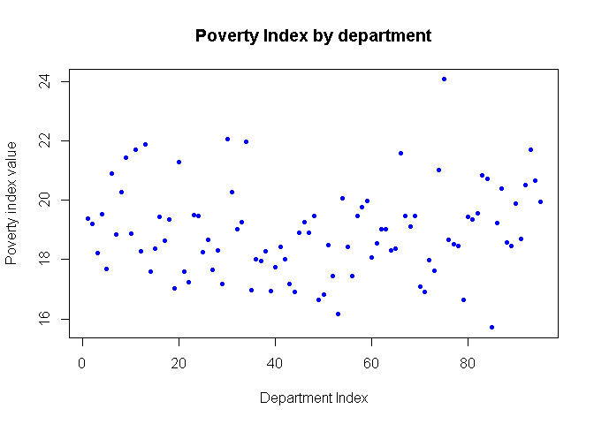

```r
# A simple plot of poverty index

plot(crimes$poverty_index, main="Poverty Index by department", xlab="Department Index",
     ylab="Poverty index value", type="p", pch=20, cex=1, col="blue")
```

The basic information needed to get a simple plot is the name of variable. More options can be then added to improve the plot. For the above graphic showing poverty index for instance, we can add the following options:

*main*: is used to give a general title to the graph.

*xlab*: is used to give a title to $x$ axis. It should be noted that the $x$ axis title in an univariate plot is just the index order of observations in the sample. In the present case, as departments are sorted by their code (from 1 for “*Ain*” to 95 for “*Val-d’Oise*”) they appear with this order on the $x$ axis, and so their position on the plot is given according to the same order.

*ylab*: is used to give a title to $y$ axis.

*type*: This option is used to choose the graph type (“$p$” for points. Other types: “*l*” for lines, “*o*” for both point and lines. For more details you can refer to the help using, **help(plot.default)**.

*pch*: is used to choose a plotting symbols such as solid lines, filled circle, filled square, etc. See **help(pch)** for a complete list.

*cex*: is a numerical vector giving the amount by which plotting characters and symbols should be scaled relative to the given default.

*col*: is used to give color name or code of the type of plotting.

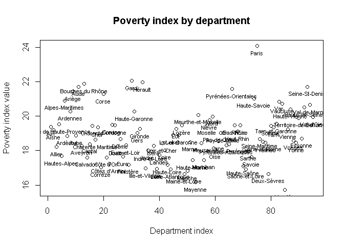

```
## integer(0)
```

```r
# Plot of poverty index using "department name" as labels on the observations points.

plot(crimes$poverty_index, main="Poverty index by department", xlab="Department index",
     ylab="Poverty index value", type="p") +
text(crimes$poverty_index, labels=crimes$dep_name, cex=0.7, pos=1)
```

**Histogram plot**

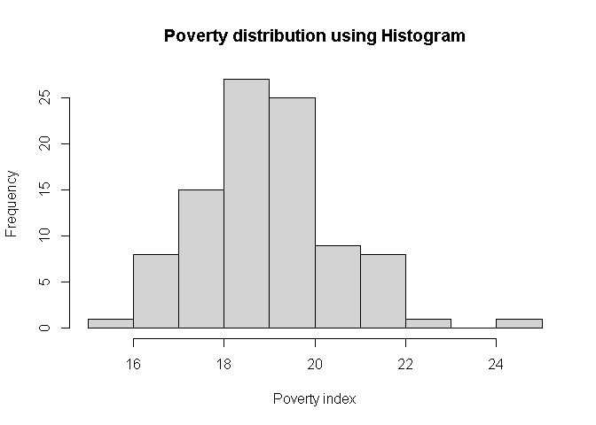

```r
# Plotting of poverty index distribution using the Histogram plot

hist(crimes$poverty_index, main="Poverty distribution using Histogram",
     xlab="Poverty index")
```

**Density plot**

```r
# Calculating density (Kernel Density Estimation)

dens <- density(crimes$poverty_index, bw="nrd0", kernel="epanechnikov", na.rm = TRUE)
```

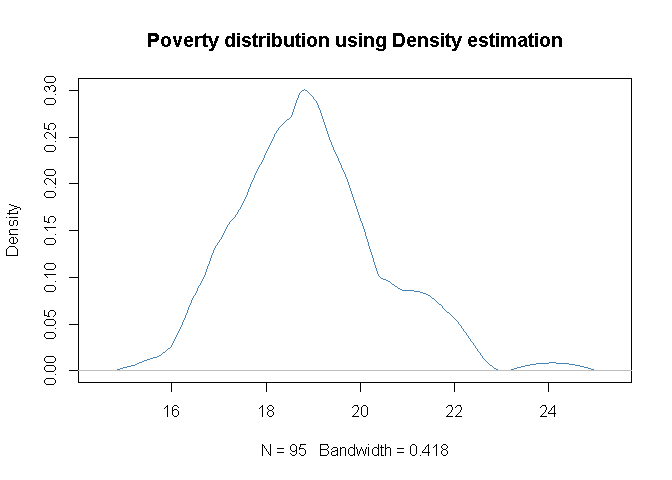

```r
# Plotting of poverty distribution using the calculated density

plot(dens, frame = TRUE, col = "steelblue", cex=1.5,
     main = "Poverty distribution using Density estimation")
```

As a non-parametric method, the kernel density estimation is considered an extension of the histogram. Compared to the latter, it produces a smoothed density line that makes it easy to interpret the empirical distribution of the variable under study.

## Univariate analysis of qualitative data

To analyse the qualitative (categorical) variables such as education level, gender, job occupation, and so on, the first step consists of counting the number of each category, and then computing its proportion in the sample.

```r
# Counting the number of departments in each region. The variable "big_region" is computed by aggregating 22 French regions (following the division of the regions before 2016) in six big regions (1. North-East, 2. North-West, 3. Ile-de-France, 4.Center, 5.South-East, 6. South-West)

# We use the "table()" function for counting.
table(crimes$big_region)
```

```
##
##  1  2  3  4  5  6
## 23 14  8  6 24 20
```

knowing the number of departments in each big region is the starting point in the description of this variable. To know the relative weight of each region, it is more meaningful to compute its proportion (percentage) in the total.

```r
# install.packages("questionr") # remove the # symbol at the beginning to install the # package

library("questionr")  # likewise, remove the # symbol to load the package
freq(crimes$big_region, cum=TRUE, sort=TRUE, valid=FALSE, total=TRUE, na.last=TRUE)
```

|  | n | % | %cum |
| --- | --- | --- | --- |
| 1 | 23 | 24.2 | 24.2 |
| 2 | 14 | 14.7 | 38.9 |
| 3 | 8 | 8.4 | 47.4 |
| 4 | 6 | 6.3 | 53.7 |
| 5 | 24 | 25.3 | 78.9 |
| 6 | 20 | 21.1 | 100.0 |
| Total | 95 | 100.0 | 100.0 |

## Bivariate analysis of quantitative data

When checking for the link between two variables, we can either draw a scatter plot or compute the correlation coefficient to evaluate quantitatively that link.

**Plotting relationship between variables**

To draw the scatter plot between crimes and poverty, we can use the same **plot ()** function seen above.

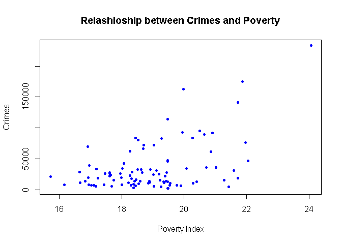

```r
# Scatter plot between "crimes" and "poverty_index"

plot(x=crimes$poverty_index, y=crimes$crimes,
     main="Relashioship between Crimes and Poverty", xlab="Poverty Index",
     ylab="Crimes", type="p", pch=20, cex=1, col="blue")
```

From the scatter plot between crimes and poverty, we can observe a positive link in the sense that for regions or departments with low levels of poverty correspond also to low level of crimes. The contrary is true, but with more dispersion than for the lower levels of crimes and poverty.

**Computing the correlation coefficient**

We can test association between two quantitative variables, using the **cor()** function. It allows the use of the three traditional methods to compute the correlation coefficient: Pearson’s product moment correlation coefficient, Kendall’s $tau$ or Spearman’s $rho$.

```r
# Computing the correlation coefficient between "crimes" and "poverty_index' using the Pearson method.

cor(crimes$crimes, crimes$poverty_index, method="pearson")
```

```
## [1] 0.4988923
```

The obtained coefficient of 0.50 is positive confirming the link shown in the scatter plot. But at this step, we just observe the correlation level. We can not make conclusions about it. In order to do so we should run a test on statistical significance. As the link is supposed to be linear the t-Student type test can be chosen in this case.

The function in *R* that computes the correlation coefficient while running the statistical significance test is **cor.test()**.

```r
# Performing the statistical significance test of the correlation between "crimes" and "poverty_index" using "pearson" method.

cor.test(crimes$crimes, crimes$poverty_index, alternative="two.sided",
         method="pearson", conf.level=0.95)
```

```
##
##  Pearson's product-moment correlation
##
## data:  crimes$crimes and crimes$poverty_index
## t = 5.5513, df = 93, p-value = 2.666e-07
## alternative hypothesis: true correlation is not equal to 0
## 95 percent confidence interval:
##  0.3305895 0.6364422
## sample estimates:
##       cor
## 0.4988923
```

```r
# Performing the test for statistical significance of the correlation between "crimes" and "poverty_index" using "spearman" method, which is a non-parametric one. This method is suited when the supposed link between variables is not linear.

cor.test(crimes$crimes, crimes$poverty_index, alternative="two.sided",
         method="spearman", conf.level=0.95)
```

```
##
##  Spearman's rank correlation rho
##
## data:  crimes$crimes and crimes$poverty_index
## S = 102527, p-value = 0.005554
## alternative hypothesis: true rho is not equal to 0
## sample estimates:
##       rho
## 0.2824267
```

The tested null hypothesis $H_{0}$ is defined as follow: *true correlation equals to zero*. The Student-test output shows a $p-value$ equals to zero allowing to reject the $H_{0}$ hypothesis in favour of the alternative one $H_{1}$ (*true correlation is not equal to 0*) and then concluding that the observed link between crimes and poverty is statistically significant.

## Bivariate analysis of qualitative data

To test the association between two categorical variables we interact them in a cross table. This cross-tabulation can be used to derive three probability laws: *joint probability*, *marginal probability* and *conditional probability* that are the base of elaborating and estimating more advanced probability models.

Cross tabulating also allows to test the independence between two categorical variables using the Chi-square $\chi$ test.

**Cross-tabulation**

To perform the interaction between two categorical variables, we create from *crimes* and *poverty_index* two new versions based on the mean of each of them, as the threshold of division into 0 and 1 categories. Thus, the new categorical variable is a dummy variable equals to one if the value of the original quantitative variable is greater than its mean and 0 otherwise.

For the interpretation of the dummy variable of crimes, for instance, level one indicates that the corresponding department belongs to the high crime category and level zero indicates the contrary.

To create dummies we use the **ifelse()** function that allows to test a conditional statement ($ifelse (condition, yes, no)$) and returns two responses: $yes$ if the condition is TRUE and $no$ if it is FALSE.

```r
# Creating a dummy for "crimes", named 'crim_degree' based on the mean threshold of "crimes".

crimes$crim_degree <- ifelse(crimes$crimes>mean(crimes$crimes), 1,0 )

# Creating a dummy for "poverty_index", named 'poverty_cat' based on the mean threshold of "poverty_index".

crimes$poverty_cat <- ifelse(crimes$poverty_index>mean(crimes$poverty_index),1,0)
```

There are many ways to get a cross-taulation in *R*. We choose in this application to use the **CrossTable()** function because its implementation is similar to *S-Plus* *crosstabs()* and *SAS* *Proc Freq* (or *SPSS* format). Moreover, it performs Chi-square, Fisher and McNemar tests of the independence of all table factors. To get more information on this function see the help using *? CrossTable()*.

```r
# Performing cross-tabulation between "crim_degree" and "poverty_cat" using "CrossTable()" function.

# Insalling the package "gmodels" to get "CrossTable()" function.
#install.packages("gmodels")  # Remove # symbol to install.

# Loading the package "gmodels" in memory.
library("gmodels")

CrossTable(crimes$crim_degree, crimes$poverty_cat, digits=2,
          prop.chisq=FALSE, chisq=FALSE,fisher=FALSE,mcnemar=FALSE,
          missing.include = FALSE, format="SPSS")
```

```
##
##    Cell Contents
## |-------------------------|
## |                   Count |
## |             Row Percent |
## |          Column Percent |
## |           Total Percent |
## |-------------------------|
##
## Total Observations in Table:  95
##
##                    | crimes$poverty_cat
## crimes$crim_degree |        0  |        1  | Row Total |
## -------------------|-----------|-----------|-----------|
##                  0 |       43  |       26  |       69  |
##                    |    62.32% |    37.68% |    72.63% |
##                    |    84.31% |    59.09% |           |
##                    |    45.26% |    27.37% |           |
## -------------------|-----------|-----------|-----------|
##                  1 |        8  |       18  |       26  |
##                    |    30.77% |    69.23% |    27.37% |
##                    |    15.69% |    40.91% |           |
##                    |     8.42% |    18.95% |           |
## -------------------|-----------|-----------|-----------|
##       Column Total |       51  |       44  |       95  |
##                    |    53.68% |    46.32% |           |
## -------------------|-----------|-----------|-----------|
##
##
```

**Testing the independence between categorical variables**

To check the association between crimes and poverty, as categorical variables, we use the Chi-square test of independence. One of the advantages of the *CrossTable()* is the possibility to run Chi-square, Fisher, and McNemar tests of the independence of all table factors. The null hypothesis ($H_{0}$) tested is stated as follows: *all table factors are independent*.

```r
# Testing the independence between the crimes levels ("cri_degree") and poverty intensity (poverty_cat) expressed as dummy variables using Chi-square test.

CrossTable(crimes$crim_degree,crimes$poverty_cat, digits=2, prop.chisq=FALSE, chisq=TRUE,fisher=FALSE,mcnemar=FALSE, missing.include = FALSE,format="SPSS")
```

```
##
##    Cell Contents
## |-------------------------|
## |                   Count |
## |             Row Percent |
## |          Column Percent |
## |           Total Percent |
## |-------------------------|
##
## Total Observations in Table:  95
##
##                    | crimes$poverty_cat
## crimes$crim_degree |        0  |        1  | Row Total |
## -------------------|-----------|-----------|-----------|
##                  0 |       43  |       26  |       69  |
##                    |    62.32% |    37.68% |    72.63% |
##                    |    84.31% |    59.09% |           |
##                    |    45.26% |    27.37% |           |
## -------------------|-----------|-----------|-----------|
##                  1 |        8  |       18  |       26  |
##                    |    30.77% |    69.23% |    27.37% |
##                    |    15.69% |    40.91% |           |
##                    |     8.42% |    18.95% |           |
## -------------------|-----------|-----------|-----------|
##       Column Total |       51  |       44  |       95  |
##                    |    53.68% |    46.32% |           |
## -------------------|-----------|-----------|-----------|
##
##
## Statistics for All Table Factors
##
##
## Pearson's Chi-squared test
## ------------------------------------------------------------
## Chi^2 =  7.559815     d.f. =  1     p =  0.005968411
##
## Pearson's Chi-squared test with Yates' continuity correction
## ------------------------------------------------------------
## Chi^2 =  6.344185     d.f. =  1     p =  0.01177667
##
##
##        Minimum expected frequency: 12.04211
```

To get the Chi-square test when computing frequencies, the same code as above is used. We just add the TRUE option to Chi-square test.

From the Chi-square test output, the $p-value$ is equals to 0.005 which allows us to reject the null hypothesis of independence at the level of 1% of statistical significance. We then conclude that crimes degree is significantly associated with poverty levels.

# Creating more advanced plots with *ggplot2*

**ggplot2** is a powerful tool to perform the graphical representation of data. It was developed initially by Hadly Wichham. It can be installed by itself or as being part of the *tidyverse* package for doing data science in *R*. *ggplot2* has become rapidly the default data visualisation package for the *R* statistical programming language.

The philosophy behind *ggplot2* is to start by a simple plot and then add cumulatively other options to it by using the ‘**+**’ symbol at the end of each task.

For more information on using *ggplot* check the help (*? ggplot*) or see this [online page](https://ggplot2.tidyverse.org/).

The following plot compares the scatter plot graphic got by the generic *plot()* function previously with that of *ggplot2*.

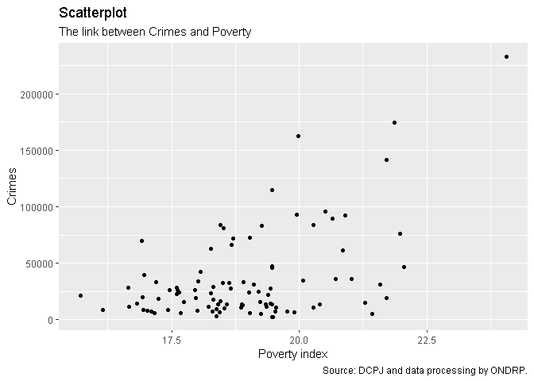

```r
# Scatter plot of "crimes" and "poverty_index" using 'ggplot2'.
# First, we load 'ggplot2' in memory using 'library()'.

library("ggplot2")

ggplot(crimes, aes(x=poverty_index, y=crimes)) +
  geom_point() +   # Show dots
  labs(subtitle="The link between Crimes and Poverty",
       x="Poverty index",
       y="Crimes",
       title="Scatterplot",
     caption = "Source: DCPJ and data processing by ONDRP.")
```

**Linear adjustment**

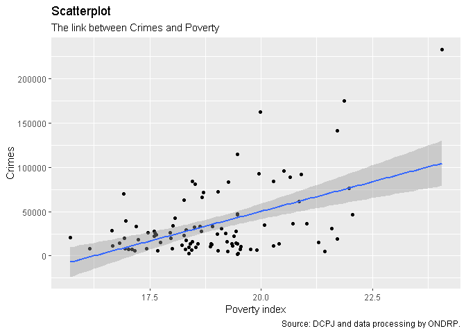

```r
# Adding a linear adjustment (regression line) with confidence interval around the line.

ggplot(crimes, aes(x=poverty_index, y=crimes)) +
  geom_point() +   # Show dots
  labs(subtitle="The link between Crimes and Poverty",
       x="Poverty index",
       y="Crimes",
       title="Scatterplot",
     caption = "Source: DCPJ and data processing by ONDRP.") +
  geom_smooth(method=lm)
```

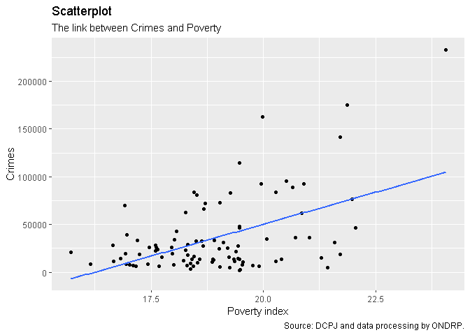

```r
# Adding a linear adjustment (regression line) without the confidence interval draw.

ggplot(crimes, aes(x=poverty_index, y=crimes)) +
  geom_point() +   # Show dots
  labs(subtitle="The link between Crimes and Poverty",
       x="Poverty index",
       y="Crimes",
       title="Scatterplot",
     caption = "Source: DCPJ and data processing by ONDRP.") +
  geom_smooth(method=lm, se=FALSE)
```

**Non-linear adjustment (*loess*)**

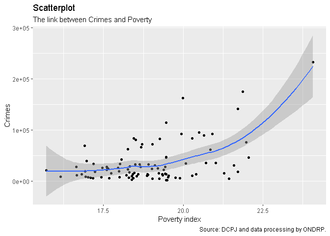

```r
# Adding a non-linear adjustment using  the LOcally Estimated Scatter plot Smoothing (loess) and showing confidence interval draw.

ggplot(crimes, aes(x=poverty_index, y=crimes)) +
  geom_point() +   # Show dots
  labs(subtitle="The link between Crimes and Poverty",
       x="Poverty index",
       y="Crimes",
       title="Scatterplot",
     caption = "Source: DCPJ and data processing by ONDRP.") +
  geom_smooth(method=loess, se=TRUE)
```

# Estimating the linear model (regression) parameters

Linear modelling is a framework to model causality link between two variables, the output variable, $y$, and the input variable $x$ when the presupposed relationship linking them is linear. In economics, $y$ is called the *explained*, *dependent*, or *endogenous* variable, while the $x$ is named, *explanatory*, *independent* or *exogenous* variable(s).

The regression technique may be used in practice to achieve one of these three main objectives:

1. Analysing the relationship between two or more variables.
2. Predicting the value of the explained variable ($y$) as a function of a given level of the explanatory variable(s) ($x$).
3. Determining the effect (impact) of $x$ on $y$.

When dealing with linear modelling, we distinguish between the mathematical model $y= f(x)$ where $f(x)$ is a function of $x$ and a statistical model that allows to estimate the link between $x$ and $y$.

By supposing linearity of the $x$ function in $x$, we obtain the following deterministic statistical model:

$$\begin{equation}
\tag{1}
f(x)= \alpha + \beta x
\end{equation}$$

The stochastic linear regression equation is obtained by the addition of a random $error$ term supposed to capture any omitted (unobserved) factor from the model specification.

The random regression equation can be written as follow:

$$\begin{equation}
\tag{2}
y = \alpha + \beta x + \epsilon
\end{equation}$$

Where,

$y$: is the endogenous (explained) variable.

$x$: is the exogenous variable or a vector if there is more than one variable.

$\alpha$ and $\beta$: are the unknown coefficients to be estimated from the data using estimation techniques such as, Ordinary Least Squares (OLS), Generalized Methods of Moments (GMM) or Maximum Likelihood estimator (ML).

$\epsilon$: is the error term supposed to be independent and identically distributed ($i.i.d.$)

The term that appears most important when we estimate the parameters of the equation (2), is the error term ($\epsilon$). Indeed, as the error term captures all factors omitted from the model, the main objective is to find, as far as possible, a specification which makes it possible to minimize this term.

In order for the linear regression model to be properly applied, it must meet a number of criteria. Without being exhaustive, a reliable estimate must respect the following constraints:

1. Linearity link between the response ($y$) and the predictor(s) ($x$).
2. Independence of error terms (absence of auto-correlation).
3. Homoscedasticity of errors (Constant variance of error terms).
4. Independence of predictors (Absence of collinearity).
5. Absence of outliers or high-leverage points.

Among the above constraints on the use of the linear framework, the first, third, and forth must be checked every time it is a question of estimating the coefficients of the linear model. Otherwise, the estimates we obtain may be biased. In the application that follows we will assess each of these issues and introduce the *R* functions that deal with each of them.

## OLS estimation of the linear regression model

Different alternatives may be used to estimate linear model parameters. The OLS method is the most frequently used method in the empirical studies to estimate the linear regression model coefficients.

From equation 2, we can write:

$$\begin{equation}
\tag{3}
\epsilon_{i}=y_{i}-\alpha - \beta x_{i}
\end{equation}$$

The main objective of each estimation is to minimise the $\epsilon_{i}$ term. We may choose between two possibilities:

1. $min \sum|u_{i}|$
2. $min \sum(\epsilon{i})^{2}$

Following the second proposition, we put $S=\sum(\epsilon{i})^{2}$

$$\begin{equation}
\tag{4}
= \sum(y_{i}-\alpha-\beta x_{i})^2
\end{equation}$$

Let $\widehat{\alpha}$ and $\widehat{\beta}$ two estimators for $\alpha$ and $\beta$, respectively. To obtain $\widehat{\alpha}$ and $\widehat{\beta}$, we derive from the equation 4 with respect to $\alpha$ and then to $\beta$.

The derivative with respect to $\alpha$ is:

$$\begin{equation}
\tag{5}
\frac{\partial S}{\partial \alpha}=-2\sum(y_{i} - \alpha - \beta x_{i})
\end{equation}$$

The derivative with respect to $\beta$ is:

$$\begin{equation}
\tag{6}
\frac{\partial S}{\partial \beta}=-2\sum x_{i}(y_{i} - \alpha - \beta x_{i})
\end{equation}$$

By putting equations 5 and 6 equal to zero we obtain the two following normal equations:

$$\begin{equation}
\tag{7}
-2\sum(y_{i} - \alpha - \beta x_{i})= 0
\end{equation}$$

$$\begin{equation}
\tag{8}
-2\sum x_{i}(y_{i} - \alpha - \beta x_{i})= 0
\end{equation}$$

By solving algebraically the equation (7) we get the estimator $\widehat{\alpha}$ of $\alpha$ as follows:

$$\begin{equation}
\tag{9}
\widehat{\alpha}= \bar{y} - \widehat{\beta} \bar{x}
\end{equation}$$

By replacing the value of $\widehat{\alpha}$ got from (9) into the equation (8) and solving, we obtain the estimator $\widehat{\beta}$ of $\beta$:

$$\begin{equation}
\tag{10}
\widehat{\beta}= \frac{\sum({x_{i}-\bar{x}}) (y_{i}-\bar{y})}{\sum({x_{i}-\bar{x}})^{2}}
\end{equation}$$

By replacing the two estimators $\widehat{\alpha}$ and $\widehat{\beta}$ into the equation 3, we obtain the estimated errors value (*residuals*) as follow:

$$\begin{equation}
\tag{11}
\widehat{\epsilon{i}}=y_{i} - \widehat{\alpha} - \widehat{\beta} x_{i}
\end{equation}$$

Since $\;\;\widehat{y}= \widehat{\alpha} + \widehat{\beta} x_{i}$, we can also write $\;\;\widehat{\epsilon{i}}=y_{i}-\widehat{y}$

## Application. The determinants of crime

In this application the objective is to estimate the determinants of crime using French data in 2011 on crimes. The variable crimes that we consider as the dependent variable, include also all committed *incidents* and *offences* by department. It is obtained from *Direction Centrale de la Police Judiciaire (DCPJ)*. The rest of variables is collected from the site of the French National Institute of Statistics and Economic Studies (INSEE). To get information about the variables’ definition, you could also refer to the sheet named variables in the provided Excel file.

The available variables in the “*crimes.xls*” file are:

- **dep_code**: French departments’ code (from 1,…,95).
- **dep_name**: Departments’ name.
- **region_name**: Regions’ name.
- **gdp_2011**: Gross domestic product in 2011 by department.
- **crimes**: Total number of committed crimes, incidents, and offences in 2011 by department.
- **poverty_index**: Poverty ratio, given by department.
- **population**: Total number of population by department.
- **unemp_rate**: Unemployment rate by department.
- **big_region**: Large regions, is a variable computed by summing the existing  
  French regions, to have six large geographic areas. So, every big region contains a different number of departments.

**Main question**

In this study case, suppose that we have done first a literature review on the determinants of crime and we have found some explanations to the criminal behaviour. We then have chosen to focus on the socio-economic determinants. The objective is to try to explain criminal behaviour due to socio-economic factors. Moreover, we aim at assessing if there exists a heterogeneity between regions in terms of criminality.

The empirical equation to be estimated can be written as follows:

$$\begin{equation}
\tag{12}
crimes_{i}= \alpha + \beta_{1} gdp_{i} + \beta_{2} poverty_{i} + \beta_{3} unemp_{i} + \beta_{4} population_{i} + \epsilon_{i}
\end{equation}$$

**Descriptive Statistics**

Before performing descriptive statistics, we create a temporary database from *crimes* by keeping only variables to be analysed and neglecting character variables such as the department and regions names.

```r
# Creating a temporary data "crim_tab" containing the main variables, using the functions "subset()" and "select()".

crim_tab <- subset(crimes, select=c(crimes, gdp_2011,poverty_index,unemp_rate,
                  population, big_region) )
```

```r
# Checking the columns names in "crim_tab".
names(crim_tab)
```

```
## [1] "crimes"        "gdp_2011"      "poverty_index" "unemp_rate"
## [5] "population"    "big_region"
```

The new data file *crim_tab* contains now the retained six variables.

```r
# Showing the variables type using "str()" command.
str(crim_tab)
```

```
## tibble [95 x 6] (S3: tbl_df/tbl/data.frame)
##  $ crimes       : num [1:95] 21953 25201 11840 7496 6016 ...
##  $ gdp_2011     : num [1:95] 193696 44799 33428 140502 140502 ...
##  $ poverty_index: num [1:95] 19.4 19.2 18.2 19.5 17.7 ...
##  $ unemp_rate   : num [1:95] 7.2 14.1 10.5 12 9.2 10.6 10.6 12.2 12.2 12.3 ...
##  $ population   : num [1:95] 621095 555941 353036 166014 143962 ...
##  $ big_region   : num [1:95] 5 1 5 5 5 5 5 1 6 1 ...
```

We can then show the entire dataset using **View()** command or just part of it, by using either **head()** or **tail()** *R* commands seen before.

**attach() command**

The *attach()* command is very useful because it allows specifying as reference the main database that we are using, and then analyses its variables by just calling their names without mentioning any more the data frame.

```r
# Taking the database "crim_tab" as main reference.
attach(crim_tab)
```

```
## L'objet suivant est masqué _par_ .GlobalEnv:
##
##     crimes
```

```
## L'objet suivant est masqué depuis package:tidyr:
##
##     population
```

Once the “crim_tab” database is attached to the *R* search path, variables can now be evaluated without the need to refer to it by using the dollar symbol (**$**).

```r
# Performing descriptive statistics for all variables in one step.

summary(crim_tab, digits=2)
```

```
##      crimes          gdp_2011      poverty_index   unemp_rate
##  Min.   :  2200   Min.   :  7924   Min.   :16    Min.   : 5.9
##  1st Qu.: 11213   1st Qu.: 44244   1st Qu.:18    1st Qu.: 8.6
##  Median : 22422   Median : 66372   Median :19    Median : 9.8
##  Mean   : 36153   Mean   :121086   Mean   :19    Mean   : 9.9
##  3rd Qu.: 40970   3rd Qu.:100646   3rd Qu.:20    3rd Qu.:10.8
##  Max.   :232969   Max.   :601229   Max.   :24    Max.   :15.4
##    population        big_region
##  Min.   :  81372   Min.   :1.0
##  1st Qu.: 318725   1st Qu.:2.0
##  Median : 555941   Median :4.0
##  Mean   : 679212   Mean   :3.6
##  3rd Qu.: 878819   3rd Qu.:5.0
##  Max.   :2620067   Max.   :6.0
```

The variable “crimes” seems very heterogeneous among the different departments. Its minimum is 2200 incidents, while the maximum is 232969. This difference is in part due to the size of department, but probably to other factors too. This is why it is very interesting to run a multivariate regression model that takes into account several factors.

To know which department have the minimum and the maximum values, we can use the conditional statements in *R* or just do filtering by subsetting data.

```r
# Showing which department has the minimum crime number in the sample.
# it should be noted that the database used here is "crimes" which contains all variables.

subset(crimes, crimes==min(crimes), select=c(dep_name, crimes))
```

| dep_name | crimes |
| --- | --- |
| Lozère | 2200 |

```r
# Showing which department has the maximum crime number in the sample.

subset(crimes, crimes==max(crimes), select=c(dep_name, crimes))
```

| dep_name | crimes |
| --- | --- |
| Paris | 232969 |

To get a general idea on the links between variables before the modelling step, we can apply the *plot()* function on the data file. The output (see below) will be a kind of matrix plot where each variable, placed in the diagonal side, is plotted against the other variables in the sample. It is a convenient way to understand the correlation between variables in just one step.

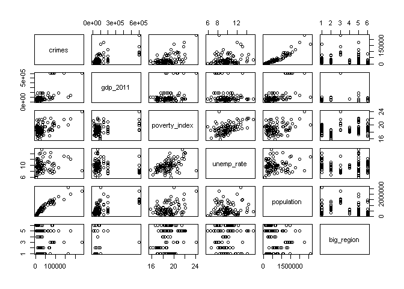

```r
# Scatter plots of the variables of interest.

corr_plot <- plot(crim_tab)
```

We can do the same thing for the correlation coefficients. To get a correlation matrix of all variables we apply the *cor ()* function on the *crim_tab*.

```r
# Correlation coefficients matrix.

cor(crim_tab, method="pearson")
```

```
##                    crimes     gdp_2011 poverty_index  unemp_rate  population
## crimes         1.00000000  0.620191498     0.4988923  0.12697913  0.94073581
## gdp_2011       0.62019150  1.000000000     0.2909976 -0.17021780  0.55976838
## poverty_index  0.49889230  0.290997645     1.0000000  0.50360245  0.33095977
## unemp_rate     0.12697913 -0.170217802     0.5036025  1.00000000  0.06829055
## population     0.94073581  0.559768381     0.3309598  0.06829055  1.00000000
## big_region    -0.07460126  0.007634428     0.2625199 -0.03283176 -0.16476128
##                 big_region
## crimes        -0.074601259
## gdp_2011       0.007634428
## poverty_index  0.262519859
## unemp_rate    -0.032831762
## population    -0.164761278
## big_region     1.000000000
```

To control the number of decimal, we use the **round()** function, also available in many other software and languages.

```r
# Correlation coefficients matrix, while limiting the decimals' number to 2 digits using the _round()_ function.

round(cor(crim_tab, method="pearson"), 2)
```

```
##               crimes gdp_2011 poverty_index unemp_rate population big_region
## crimes          1.00     0.62          0.50       0.13       0.94      -0.07
## gdp_2011        0.62     1.00          0.29      -0.17       0.56       0.01
## poverty_index   0.50     0.29          1.00       0.50       0.33       0.26
## unemp_rate      0.13    -0.17          0.50       1.00       0.07      -0.03
## population      0.94     0.56          0.33       0.07       1.00      -0.16
## big_region     -0.07     0.01          0.26      -0.03      -0.16       1.00
```

It is more interesting to combine graphics and correlation coefficients together to describe by one single image the links between variables. For that we use **ggpairs ()** function that is part of **GGally {}** package.

```r
# Installing "GGally{}" package.

# install.packages("GGally")  # Remove the # symbol to start installing.
```

```r
# Load in memory the "GGally{}" package

library("GGally")
```

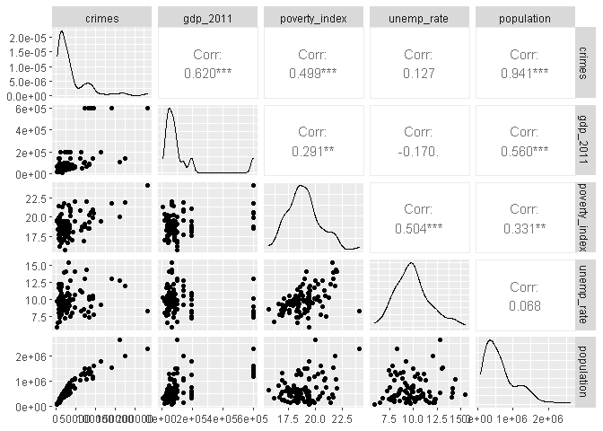

```r
# Performing scatter plots and correlation coefficients matrix in one step using "ggpairs()" function.

ggpairs(crim_tab, columns =1:5)
```

We can find in the matrix above three types of information, the estimation density of every single variable on the diagonal side, the correlation coefficients of each pair of variables on the right side of the diagonal and finally the scatter plot of each variable couple on the left side.

From the correlation matrix, the crimes are positively and significantly linked to the gross domestic product as a measure of wealth (*gdp_2011*), poverty (*poverty_index*), and the population as an approximation of the department size. The correlation of unemployment with crimes is positive but not significant.

The links between the exogenous variables (*gdp_2011*, *poverty_index*, *population*) are not very high which is an indication of the absence of collinearity when estimating model’s coefficients. It doesn’t impede, however, the possible presence of multi-collinearity which needs more investigation.

The analysis of correlation between variables is interesting in giving a first look before going further in modelling, but it remains properly descriptive because it is well known that **correlation** *is far from being* **causality**.

**Estimation of crime determinants**

The *R* function that deals with linear models is **lm()**. It can be used to perform regression, analysis of variance and covariance.

In the following, we will apply the *lm()* function to estimate the coefficients of equation (12).

```r
# Estimating regression coefficients using "lm()" function.

MyModel <- lm(crimes ~ gdp_2011 + poverty_index + unemp_rate + population, data=crimes)
```

In the previous code of fitting *lm()* function, the results (output) are assigned to the name *MyModel* that is given by the user. The main feature in the *lm()* function is the writing of **formula**. The latter is written in the same style as the mathematical equation (12). The dependent variable is put first, followed by the independent variables, each of them separated by the ‘**+**’ symbol. We notice moreover that the dependent variable is separated from the other variables by the *Tilde* symbol (**~**).

```r
# Checking the cotent of "MyModel" object.

names(MyModel)
```

```
##  [1] "coefficients"  "residuals"     "effects"       "rank"
##  [5] "fitted.values" "assign"        "qr"            "df.residual"
##  [9] "xlevels"       "call"          "terms"         "model"
```

Once the *lm()* function executed, the results are stored in different objects that can be summarised using the *summary()* function or used for other tasks.

```r
# Summarising the regression results.
# The option "(scipen=999)" is added to avoid the output of numbers with scientific notation.

options(scipen=999)
summary(MyModel)
```

```
##
## Call:
## lm(formula = crimes ~ gdp_2011 + poverty_index + unemp_rate +
##     population, data = crimes)
##
## Residuals:
##    Min     1Q Median     3Q    Max
## -22583  -6331    417   3965  51109
##
## Coefficients:
##                     Estimate     Std. Error t value             Pr(>|t|)
## (Intercept)   -113192.629274   14710.580671  -7.695      0.0000000000173 ***
## gdp_2011            0.026048       0.009471   2.750               0.0072 **
## poverty_index    5567.478109     955.966336   5.824      0.0000000877128 ***
## unemp_rate       -362.333327     754.301177  -0.480               0.6321
## population          0.065237       0.002717  24.011 < 0.0000000000000002 ***
## ---
## Signif. codes:  0 '***' 0.001 '**' 0.01 '*' 0.05 '.' 0.1 ' ' 1
##
## Residual standard error: 10710 on 90 degrees of freedom
## Multiple R-squared:  0.9322, Adjusted R-squared:  0.9292
## F-statistic: 309.4 on 4 and 90 DF,  p-value: < 0.00000000000000022
```

To assess the model output, we begin by looking at the null hypothesis test on the whole model. Based on the Fisher test, it stipulates that all model’s coefficients are equal to zero. The test results show that this null hypothesis is rejected at a 1% level of statistical significance, as the obtained $p-value$ is equal to 0.0000.

Thus, there exist at least one coefficient of the independent variables which is not null.

We move then to examine the independent variables’ coefficients, one by one. The coefficients’ sign of *gdp_2011* and *poverty_index* is positive and statistically significant, which indicates that the increase by one unit in the value of these variables leads to an increase of “*crimes*” by the value of the correspondent estimated coefficient. The sign of the unemployment variable is negative but not significant.

The first attempt to evaluate these results is to look at some model performance criteria such as the *Adjusted R-squared* which equals 0.9292. This indicates that the current model specification (the included independent variables) explains around 92 % of the variance of crimes, which seems at the first glance a very good performance.

However, given the information derived when performing descriptive statistics, we can have some suspicions about these results due to high heterogeneity in the relationship linking, *poverty_index*, *gdp_2011*, and *unemployment* to *crimes*.

Once regression model is performed, we can also access and use other useful information such as getting the confidence intervals, predicted values and residuals.

```r
# Getting the 95% confidence intervals of the estimated coefficients.

confint(MyModel, level=0.95)
```

```
##                           2.5 %          97.5 %
## (Intercept)   -142417.765373181 -83967.49317580
## gdp_2011            0.007233117      0.04486359
## poverty_index    3668.284127282   7466.67209033
## unemp_rate      -1860.884271549   1136.21761815
## population          0.059838758      0.07063431
```

```r
# Computing the predicted values of y (crimes).

crimes_hat <- fitted(MyModel)
```

```r
# Viewing the residuals (estimation of model errors).

View(MyModel$residuals)
```

Before trying to improve the first model estimation by solving the issues of data heterogeneity, we present in the following some further model assessment. It can give us more guidance in finding the ways of model’s improvements.

# Evaluating linear regression performance

There are many tools that can be used to assess the regression model accuracy. We present here some routines to investigate *Collinearity*, *Autocorrelation* and *Heteroscedasticity* issues

```r
# Installing the "car" package made by Fox and S. Weisberg as a companion for applied regression and diagnostics.
# https://cran.r-project.org/web/packages/car/index.html

# install.packages("car")    # Remove the # symbol to start installing.
```

```r
# Loading "car" package.

library("car")
```

**Collinearity diagnostics**

```r
# Compute the Variance Inflation Factor (VIF)

vif(MyModel)
```

```
##      gdp_2011 poverty_index    unemp_rate    population
##      1.729439      1.689981      1.585041      1.539028
```

```r
# Logic test of the presence of Variance Inflation problem. We may have multi-collinearity problem if the VIF statistic is superior to 2.

sqrt(vif(MyModel)) > 2
```

```
##      gdp_2011 poverty_index    unemp_rate    population
##         FALSE         FALSE         FALSE         FALSE
```

**Autocorrelation Diagnostics**

```r
# Test for Autocorrelated errors

durbinWatsonTest(MyModel)
```

```
##  lag Autocorrelation D-W Statistic p-value
##    1      -0.1646371      2.302881   0.168
##  Alternative hypothesis: rho != 0
```

**Heteroscedasticity test**

```r
# Computing non-constant error variance test.

# Null hypothesis H0:  Constant error variance.
# Alternative hypothesis H1: The error variance changes with the level of the response (fitted values), or with a linear combination of predictors.

ncvTest(MyModel)
```

```
## Non-constant Variance Score Test
## Variance formula: ~ fitted.values
## Chisquare = 119.7078, Df = 1, p = < 0.000000000000000222
```

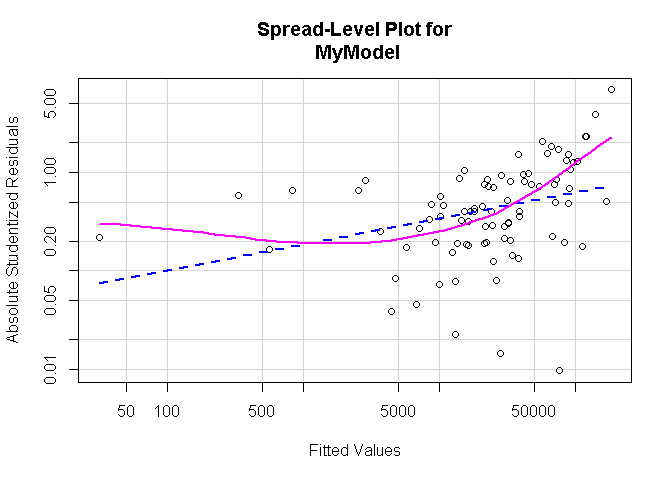

```
##
## Suggested power transformation:  0.7343701
```

```r
# Plotting residuals versus fitted values
spreadLevelPlot(MyModel)
```

**Data heterogeneity (outliers)**

```r
# Assessing outliers. Compute the Bonferonni p-value for most extreme observations.
outlierTest(MyModel)
```

```
##    rstudent unadjusted p-value   Bonferroni p
## 75 6.836023   0.00000000098289 0.000000093374
## 13 3.897175   0.00018820000000 0.017879000000
```

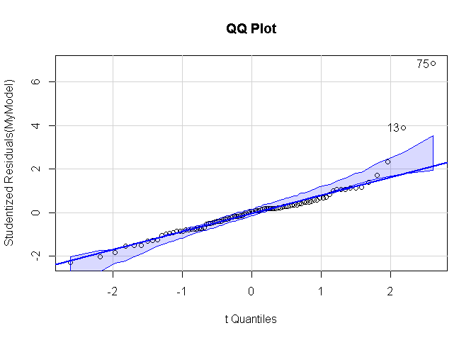

```
## [1] 13 75
```

```r
# Assessing outliers. Draw the qq plot for studentised residuals.

qqPlot(MyModel, main="QQ Plot")
```

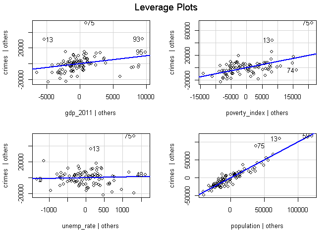

```r
# Assessing the outliers and influential observations.

leveragePlots(MyModel)
```

# Model improvement: variables scaling

The logarithmic scale has many advantages. In addition to linearizing the link between two variables, this transformation enables the reduction of the dispersion of extreme observations. Moreover, the logarithmic coefficients estimated from a linear model are interpreted as elasticities.

**Logarithmic transformation**

```r
# Compute new log scale variables

crimes$lcrimes_cap <- log(crimes$crimes/crimes$population)
crimes$lgdp_cap <- log(crimes$gdp_2011*1000000/crimes$population)
crimes$lpop <- log(crimes$population)
```

**New estimation of crime determinants using transformed variables**

```r
# Estimating regression coefficients using "lm()" function.

MyModel_log <- lm(lcrimes_cap ~ lgdp_cap + poverty_index + unemp_rate + lpop, data=crimes)
```

```r
# Showing results of the new estimation

summary(MyModel_log)
```

```
##
## Call:
## lm(formula = lcrimes_cap ~ lgdp_cap + poverty_index + unemp_rate +
##     lpop, data = crimes)
##
## Residuals:
##      Min       1Q   Median       3Q      Max
## -0.42330 -0.09949 -0.00266  0.11402  0.47984
##
## Coefficients:
##               Estimate Std. Error t value             Pr(>|t|)
## (Intercept)   -9.88297    0.53002 -18.646 < 0.0000000000000002 ***
## lgdp_cap       0.08869    0.02521   3.517             0.000685 ***
## poverty_index  0.06202    0.01431   4.333            0.0000381 ***
## unemp_rate     0.04133    0.01150   3.594             0.000530 ***
## lpop           0.31016    0.02656  11.676 < 0.0000000000000002 ***
## ---
## Signif. codes:  0 '***' 0.001 '**' 0.01 '*' 0.05 '.' 0.1 ' ' 1
##
## Residual standard error: 0.1696 on 90 degrees of freedom
## Multiple R-squared:  0.7395, Adjusted R-squared:  0.728
## F-statistic: 63.88 on 4 and 90 DF,  p-value: < 0.00000000000000022
```

**Comparing the OLS models’ performance**

We can use different indicators to compare the former *OLS* estimation with the new one, which uses variables transformed to a logarithmic scale. We can use the well-known AIC and BIC statistics to compare these two estimates.

**“broom”** package allows computing many statistics such as **AIC** and **BIC** criteria that can be used for model selection. Thus the **glance()** function from **broom** package, can be used to compute, among others, the **R2**, **adjusted R2**, **sigma (RSE)**, **AIC**, and **BIC** statistics for each model.

```r
# Install "broom" package
# "broom" package is a component of the "tidyverse". If "tidyverse" is
# already installed, we don't need to install again "broom". We just loaded it.
# Otherwise we must install it.

# Load "broom" package
library(broom)
# Using 'glance' function to compare OLS estimates
# Statistics for the model with non-transformed variables
glance(MyModel)
```

| r.squared | adj.r.squared | sigma | statistic | p.value | df | logLik | AIC | BIC | deviance | df.residual | nobs |
| --- | --- | --- | --- | --- | --- | --- | --- | --- | --- | --- | --- |
| 0.9322053 | 0.9291922 | 10712.98 | 309.3842 | 0.000000000000000000000000000000000000000000000000001088361 | 4 | -1013.756 | 2039.512 | 2054.835 | 10329105446 | 90 | 95 |

```r
# Statistics for the model with logarithmic scale variables
glance(MyModel_log)
```

| r.squared | adj.r.squared | sigma | statistic | p.value | df | logLik | AIC | BIC | deviance | df.residual | nobs |
| --- | --- | --- | --- | --- | --- | --- | --- | --- | --- | --- | --- |
| 0.7395302 | 0.7279538 | 0.1696185 | 63.88239 | 0.0000000000000000000000001754306 | 4 | 36.31834 | -60.63669 | -45.31343 | 2.58934 | 90 | 95 |

**Comment on models comparison**

From a qualitative perspective, the variables coefficients’ sign is the same in both estimations, except for the unemployment rate factor. The estimated coefficient of this variable is negative and nonsignificant in the first case and positive and significant in the transformed model, which reflects well what we would expect: uncertainty of employment may be another dimension of poverty. It then should contribute to enhancing crime rather than reducing it.

Even if the **R**-square of the first model is very high compared to the second one, using AIC and BIC criteria allows us to select the second estimates using rescaled variables as the most appropriate to explain the socio-economic determinants of crime in the French metropolitan departments. The logarithmic regression model produces very low AIC and BIC statistics than the prior model without transformation.

# Instrumental Variables Estimator (IV)

**Violation of errors independence assumption**

In the present application to the case of crime determinants, we suspect the endogeneity of gross domestic product (gdp) as a measure of the department income (wealth) or as an approximation of the local standard of living. In fact, the omitted variables from the current specification, such as the economic local activities dynamics, the part of industrial activity, etc., could directly affect the department income which violates the independent-errors assumption. One of the major sources of endogeneity is the omitted variables problem. In this case, the endogenous bias occurs when an independent variable is correlated with the error term.

One way to correct this problem is to perform a two stage least-squares (2SLS) using the instrumental variables method (IV). This method proceeds as follows. In a first stage, a *reduced form equation* regresses the suspected endogenous variable, $x$, on the instrument, $z$, and the other independent variables of the system, $X$. The second stage equation called the *structural model*, regresses the main endogenous variable, $y$, on the predicted variable, $\hat{x}$, derived from the first stage and the other independent variables except the instrument(s).

But the correct use of this method needs to find an instrument, $z$, that should fulfils two conditions. The first one is that the candidate instrument, $z$, must be correlated with the endogenous variable, $x$, but uncorrelated with the error term, $u$:
$$Cov(x, z) \neq 0 \; \; \text{and} \;\; Cov(x, u) = 0$$

The exclusion restriction’s second condition implies that the instrument, $z$, must not be correlated with the main endogenous variable, $y$, and excluded from the structural equation.

```r
# Install the "AER" package: Kleiber, Ch., Zeileis, A. (2008). Applied Econometrics with R, Springer-Verlag

# install.packages("AER")

# Load "AER" , "lm" packages

library(AER)
```

**First stage estimation: the reduced form equation**

```r
# 1. Perform the first stage regression: reduced form equation
reducedForm <- lm(lgdp_cap ~ pupils + unemp_rate + poverty_index + lpop, data = crimes)
```

```r
# Inspecting the regression results

summary(reducedForm)
```

```
##
## Call:
## lm(formula = lgdp_cap ~ pupils + unemp_rate + poverty_index +
##     lpop, data = crimes)
##
## Residuals:
##      Min       1Q   Median       3Q      Max
## -1.94117 -0.46866 -0.03481  0.42665  1.47058
##
## Coefficients:
##               Estimate Std. Error t value             Pr(>|t|)
## (Intercept)   15.94794    1.35164  11.799 < 0.0000000000000002 ***
## pupils         0.04868    0.01222   3.984             0.000138 ***
## unemp_rate    -0.15635    0.04269  -3.662             0.000421 ***
## poverty_index  0.17779    0.05342   3.328             0.001267 **
## lpop          -0.74996    0.12633  -5.937         0.0000000537 ***
## ---
## Signif. codes:  0 '***' 0.001 '**' 0.01 '*' 0.05 '.' 0.1 ' ' 1
##
## Residual standard error: 0.6538 on 90 degrees of freedom
## Multiple R-squared:  0.3327, Adjusted R-squared:  0.3031
## F-statistic: 11.22 on 4 and 90 DF,  p-value: 0.0000001982
```

**Linear hypothesis tests**

To assess the correlation between the instrument (*pupils*) and the suspected endogenous variable (*gdp_cap*), we run a linear hypothesis test. We recall that we can’t previously test the independence hypothesis between errors and predictors. We can only do this test after estimation.

```r
# Test of statistical significance of pupils variable
# H0 assumption: the beta(pupils) coefficient is equals to zero

coeftest(reducedForm, vcov = vcovHC, type = "HC1")
```

```
##
## t test of coefficients:
##
##                Estimate Std. Error t value              Pr(>|t|)
## (Intercept)   15.947944   1.410549 11.3062 < 0.00000000000000022 ***
## pupils         0.048678   0.014486  3.3603             0.0011436 **
## unemp_rate    -0.156350   0.038936 -4.0155             0.0001227 ***
## poverty_index  0.177792   0.053083  3.3493             0.0011848 **
## lpop          -0.749962   0.145622 -5.1501           0.000001523 ***
## ---
## Signif. codes:  0 '***' 0.001 '**' 0.01 '*' 0.05 '.' 0.1 ' ' 1
```

From the linear hypothesis test of $H_{0}: \beta(pupils)=0$, this null hypothosis is rejected at 1% of statistical significance. We then conclude that the instrument *pupils* is correlated with the instrumented variable *gdp* per capita.

```r
# inspect the R^2 of the first stage regression

summary(reducedForm)$r.squared
```

```
## [1] 0.3327283
```

```r
# store the predicted values to be used in the second stage regression as
# independent variable, istead of the original variable 'pupils'


lgdp_pred <- reducedForm$fitted.values

# A second way to predict the fitted values
lgdp_pred2 <- predict(reducedForm)
```

**Second stage regression: structural equation**

The structual equation regresses the main endogenous variable (*crime*) on the estimated values of the suspected endogenous variable (*gdp_cap*) and the other exogenous regressors.

```r
# Run the second stage regression: structural equation
structuralEq <- lm(lcrimes_cap ~ lgdp_pred +  unemp_rate + poverty_index + lpop, data = crimes)

coeftest(structuralEq, vcov = vcovHC)
```

```
##
## t test of coefficients:
##
##                 Estimate Std. Error  t value              Pr(>|t|)
## (Intercept)   -13.235138   1.126544 -11.7484 < 0.00000000000000022 ***
## lgdp_pred       0.301268   0.072298   4.1670           0.000070745 ***
## unemp_rate      0.069951   0.013984   5.0023           0.000002785 ***
## poverty_index   0.029226   0.018814   1.5534                0.1238
## lpop            0.398248   0.037816  10.5313 < 0.00000000000000022 ***
## ---
## Signif. codes:  0 '***' 0.001 '**' 0.01 '*' 0.05 '.' 0.1 ' ' 1
```

```r
summary(structuralEq)
```

```
##
## Call:
## lm(formula = lcrimes_cap ~ lgdp_pred + unemp_rate + poverty_index +
##     lpop, data = crimes)
##
## Residuals:
##     Min      1Q  Median      3Q     Max
## -0.3506 -0.1263  0.0022  0.0964  0.4888
##
## Coefficients:
##                Estimate Std. Error t value             Pr(>|t|)
## (Intercept)   -13.23514    1.02928 -12.859 < 0.0000000000000002 ***
## lgdp_pred       0.30127    0.06177   4.877           0.00000462 ***
## unemp_rate      0.06995    0.01333   5.247           0.00000102 ***
## poverty_index   0.02923    0.01617   1.807               0.0741 .
## lpop            0.39825    0.03452  11.536 < 0.0000000000000002 ***
## ---
## Signif. codes:  0 '***' 0.001 '**' 0.01 '*' 0.05 '.' 0.1 ' ' 1
##
## Residual standard error: 0.1609 on 90 degrees of freedom
## Multiple R-squared:  0.7657, Adjusted R-squared:  0.7552
## F-statistic: 73.51 on 4 and 90 DF,  p-value: < 0.00000000000000022
```

**Hausman test of endogeneity**

As it is stated above before estimation there is no way to check the endogeneity assumption. The doubt of endogeneity of a given predictor is only based on theoretical considerations. After estimation Hausman test can be applied to check if the endogeneity assumption holds.

The Hausman (1978) test starts from the idea that if there is no difference between OLS and IV estimators, the predictor will be considered exogenous. Conversely, if there are systematic differences between the estimators, the suspected variable can be viewed as endogenous. The null hypothesis states: *The suspected variable is exogenous*.

Following Wooldridge (2013, p.535) the Hausman (1978) test can be applied as follows.

1. Regress the suspected endogenous variable on the instruments and exogenous variables. Predict the residuals $\hat{u}$.
2. Add the predicted residuals to the structural equation ($y$) containing also the whole exogenous variables. Run a linear coefficient test for the estimated $\hat{u}$ term from an OLS estimation.
3. The decision rule states that the suspected predictor is endogenous if the term $\hat{u}$ is significantly different from zero.

```r
# Hausman procedure to test endogeneity assumption
# Regression

HausmanTest <- lm(lgdp_cap ~ pupils +  unemp_rate + poverty_index + lpop, data = crimes)

# Predict residuals
gdp_residuals <- predict(HausmanTest)
```

```r
# Testing the significance of residuals term via a regression within the
# structural equation
endoTest <- lm(lcrimes_cap ~ lgdp_cap + unemp_rate + poverty_index + lpop +
                 gdp_residuals, data = crimes)

# Residuals term significance test

coeftest(endoTest, vcov = vcovHC)
```

```
##
## t test of coefficients:
##
##                 Estimate Std. Error  t value              Pr(>|t|)
## (Intercept)   -13.235138   1.085718 -12.1902 < 0.00000000000000022 ***
## lgdp_cap        0.051205   0.028170   1.8177             0.0724785 .
## unemp_rate      0.069951   0.013725   5.0968           0.000001926 ***
## poverty_index   0.029226   0.019183   1.5235             0.1311694
## lpop            0.398248   0.038219  10.4202 < 0.00000000000000022 ***
## gdp_residuals   0.250063   0.067417   3.7092             0.0003613 ***
## ---
## Signif. codes:  0 '***' 0.001 '**' 0.01 '*' 0.05 '.' 0.1 ' ' 1
```

**Comment on endogeneity test**

The test of *gdp_residuals* term is highly significant, allowing to reject the null hypothesis of exogeneity and concluding that *gdp_cap* is endogenous. In other words, the 2SLS regression is preferred over the OLS estimates.

**Important remark**

The objective of presenting the IV two stages procedure is to show, from a methodological point of view, how we correct for endogeneity. However, doing so the standard errors of the second stage are not correct (Wooldridge, 2013, 5e eds, p. 557). The **ivreg** function of the **AER** package fixes this issue and corrects automatically the standard errors.

```r
# IV estimator using 'ivreg' function

ivreg_est <- ivreg(lcrimes_cap ~  lgdp_cap + unemp_rate + poverty_index + lpop |
                                             unemp_rate + poverty_index + lpop +                                        pupils, data = crimes)
```

```r
# Schow the estimates results of using the 'ivreg'  function.

summary(ivreg_est)
```

```
##
## Call:
## ivreg(formula = lcrimes_cap ~ lgdp_cap + unemp_rate + poverty_index +
##     lpop | unemp_rate + poverty_index + lpop + pupils, data = crimes)
##
## Residuals:
##     Min      1Q  Median      3Q     Max
## -0.5231 -0.1715 -0.0198  0.1273  0.7555
##
## Coefficients:
##                Estimate Std. Error t value           Pr(>|t|)
## (Intercept)   -13.23514    1.45173  -9.117 0.0000000000000197 ***
## lgdp_cap        0.30127    0.08713   3.458           0.000834 ***
## unemp_rate      0.06995    0.01880   3.720           0.000346 ***
## poverty_index   0.02923    0.02281   1.281           0.203355
## lpop            0.39825    0.04869   8.179 0.0000000000017429 ***
## ---
## Signif. codes:  0 '***' 0.001 '**' 0.01 '*' 0.05 '.' 0.1 ' ' 1
##
## Residual standard error: 0.2269 on 90 degrees of freedom
## Multiple R-Squared: 0.5338,  Adjusted R-squared: 0.5131
## Wald test: 36.95 on 4 and 90 DF,  p-value: < 0.00000000000000022
```

```r
# The linear coefficients test hypothesis

coeftest(ivreg_est, vcov = vcovHC, type = "HC1")
```

```
##
## t test of coefficients:
##
##                 Estimate Std. Error t value           Pr(>|t|)
## (Intercept)   -13.235138   1.481191 -8.9355 0.0000000000000469 ***
## lgdp_cap        0.301268   0.091985  3.2752          0.0015001 **
## unemp_rate      0.069951   0.019030  3.6757          0.0004028 ***
## poverty_index   0.029226   0.028195  1.0366          0.3027049
## lpop            0.398248   0.054809  7.2661 0.0000000001289904 ***
## ---
## Signif. codes:  0 '***' 0.001 '**' 0.01 '*' 0.05 '.' 0.1 ' ' 1
```

# Panel data models

For panel data application, we use data from the **Wooldridge** package developed by Florian (2020) using data examples from the Wooldridge textbook on the *Introductory Econometrics*.

```r
# Load the "Wooldridge" package
library(wooldridge)

# Load the 'plm' package on 'Panel data econometrics in R', by Yves Croissant
# and Giovanni Millo.

library(plm)
wage <- data(wagepan)
```

**Fixef effects estimation**

```r
panel.fe <- plm(lwage ~ educ + exper + expersq + union + south + married +
                  black, data=wagepan, index=c("nr", "year"), model="within" )
```

```r
summary(panel.fe)
```

```
## Oneway (individual) effect Within Model
##
## Call:
## plm(formula = lwage ~ educ + exper + expersq + union + south +
##     married + black, data = wagepan, model = "within", index = c("nr",
##     "year"))
##
## Balanced Panel: n = 545, T = 8, N = 4360
##
## Residuals:
##      Min.   1st Qu.    Median   3rd Qu.      Max.
## -4.172253 -0.125250  0.008711  0.159802  1.483136
##
## Coefficients:
##            Estimate  Std. Error t-value              Pr(>|t|)
## exper    0.11607282  0.00842359 13.7795 < 0.00000000000000022 ***
## expersq -0.00426399  0.00060524 -7.0451     0.000000000002189 ***
## union    0.08302753  0.01928679  4.3049     0.000017127087040 ***
## south    0.10230833  0.04797245  2.1326               0.03302 *
## married  0.04482781  0.01830252  2.4493               0.01436 *
## ---
## Signif. codes:  0 '***' 0.001 '**' 0.01 '*' 0.05 '.' 0.1 ' ' 1
##
## Total Sum of Squares:    572.05
## Residual Sum of Squares: 469.64
## R-Squared:      0.17902
## Adj. R-Squared: 0.060726
## F-statistic: 166.164 on 5 and 3810 DF, p-value: < 0.000000000000000222
```

**Random effects estmations**

```r
panel.re <- plm(lwage ~ educ + exper + expersq + union + south + married +
                  black, data=wagepan, index=c("nr", "year"), model="random" )
```

```r
summary(panel.re)
```

```
## Oneway (individual) effect Random Effect Model
##    (Swamy-Arora's transformation)
##
## Call:
## plm(formula = lwage ~ educ + exper + expersq + union + south +
##     married + black, data = wagepan, model = "random", index = c("nr",
##     "year"))
##
## Balanced Panel: n = 545, T = 8, N = 4360
##
## Effects:
##                  var std.dev share
## idiosyncratic 0.1233  0.3511 0.541
## individual    0.1045  0.3233 0.459
## theta: 0.6416
##
## Residuals:
##      Min.   1st Qu.    Median   3rd Qu.      Max.
## -4.581979 -0.144723  0.023474  0.185661  1.535320
##
## Coefficients:
##                Estimate  Std. Error z-value              Pr(>|z|)
## (Intercept) -0.08919469  0.10747914 -0.8299             0.4066072
## educ         0.10021016  0.00872044 11.4914 < 0.00000000000000022 ***
## exper        0.11209364  0.00826369 13.5646 < 0.00000000000000022 ***
## expersq     -0.00406609  0.00059196 -6.8688     0.000000000006473 ***
## union        0.10752968  0.01783244  6.0300     0.000000001639555 ***
## south       -0.00896523  0.02706088 -0.3313             0.7404190
## married      0.06305148  0.01678390  3.7567             0.0001722 ***
## black       -0.14556579  0.04735074 -3.0742             0.0021107 **
## ---
## Signif. codes:  0 '***' 0.001 '**' 0.01 '*' 0.05 '.' 0.1 ' ' 1
##
## Total Sum of Squares:    657.41
## Residual Sum of Squares: 540.25
## R-Squared:      0.17822
## Adj. R-Squared: 0.1769
## Chisq: 943.838 on 7 DF, p-value: < 0.000000000000000222
```

**Hausman specification test**

```r
# Hausman specification test, to choose between models
# H0: There is no difference between the two models

phtest(panel.fe, panel.re)
```

```
##
##  Hausman Test
##
## data:  lwage ~ educ + exper + expersq + union + south + married + black
## chisq = 42.004, df = 5, p-value = 0.00000005879
## alternative hypothesis: one model is inconsistent
```

# Formatted regression tables

Results from R statistical output can be formatted as beautiful *LateX*, *HTML* and *ASCII* tables using **“stargazer”** package.

```r
# Insgtall and load the "stargazer" package
#install.packages("stargazer")
library(stargazer)
# Format regression results as a LateX table

stargazer(MyModel, MyModel_log, structuralEq, title = "Regression Results", align = TRUE)
```

```
##
## % Table created by stargazer v.5.2.2 by Marek Hlavac, Harvard University. E-mail: hlavac at fas.harvard.edu
## % Date and time: sam., janv. 01, 2022 - 22:13:46
## % Requires LaTeX packages: dcolumn
## \begin{table}[!htbp] \centering
##   \caption{Regression Results}
##   \label{}
## \begin{tabular}{@{\extracolsep{5pt}}lD{.}{.}{-3} D{.}{.}{-3} D{.}{.}{-3} }
## \\[-1.8ex]\hline
## \hline \\[-1.8ex]
##  & \multicolumn{3}{c}{\textit{Dependent variable:}} \\
## \cline{2-4}
## \\[-1.8ex] & \multicolumn{1}{c}{crimes} & \multicolumn{2}{c}{lcrimes\_cap} \\
## \\[-1.8ex] & \multicolumn{1}{c}{(1)} & \multicolumn{1}{c}{(2)} & \multicolumn{1}{c}{(3)}\\
## \hline \\[-1.8ex]
##  gdp\_2011 & 0.026^{***} &  &  \\
##   & (0.009) &  &  \\
##   & & & \\
##  lgdp\_cap &  & 0.089^{***} &  \\
##   &  & (0.025) &  \\
##   & & & \\
##  lgdp\_pred &  &  & 0.301^{***} \\
##   &  &  & (0.062) \\
##   & & & \\
##  poverty\_index & 5,567.478^{***} & 0.062^{***} & 0.029^{*} \\
##   & (955.966) & (0.014) & (0.016) \\
##   & & & \\
##  unemp\_rate & -362.333 & 0.041^{***} & 0.070^{***} \\
##   & (754.301) & (0.011) & (0.013) \\
##   & & & \\
##  population & 0.065^{***} &  &  \\
##   & (0.003) &  &  \\
##   & & & \\
##  lpop &  & 0.310^{***} & 0.398^{***} \\
##   &  & (0.027) & (0.035) \\
##   & & & \\
##  Constant & -113,192.600^{***} & -9.883^{***} & -13.235^{***} \\
##   & (14,710.580) & (0.530) & (1.029) \\
##   & & & \\
## \hline \\[-1.8ex]
## Observations & \multicolumn{1}{c}{95} & \multicolumn{1}{c}{95} & \multicolumn{1}{c}{95} \\
## R$^{2}$ & \multicolumn{1}{c}{0.932} & \multicolumn{1}{c}{0.740} & \multicolumn{1}{c}{0.766} \\
## Adjusted R$^{2}$ & \multicolumn{1}{c}{0.929} & \multicolumn{1}{c}{0.728} & \multicolumn{1}{c}{0.755} \\
## Residual Std. Error (df = 90) & \multicolumn{1}{c}{10,712.980} & \multicolumn{1}{c}{0.170} & \multicolumn{1}{c}{0.161} \\
## F Statistic (df = 4; 90) & \multicolumn{1}{c}{309.384$^{***}$} & \multicolumn{1}{c}{63.882$^{***}$} & \multicolumn{1}{c}{73.512$^{***}$} \\
## \hline
## \hline \\[-1.8ex]
## \textit{Note:}  & \multicolumn{3}{r}{$^{*}$p$<$0.1; $^{**}$p$<$0.05; $^{***}$p$<$0.01} \\
## \end{tabular}
## \end{table}
```

# To go in depth with *R*

There is a big community of researchers, scientists, and developers that produce and distribute packages, tutorials, and *R’s* courses. The majority of these materials are freely accessible on the Internet. In the reference chapter below, we give some of these materials, together with other academic publications. The most important, if not the unique advice, that we recommend is to try to learn *R* while **practicing code** (*learning by doing*), preferably by working on a real project of data analysis or econometric modeling.

# Bibliography

**Learning R**

- Arnold, J.B. (2020). [*R for Data Science: Exercise Solutions*](https://jrnold.github.io/r4ds-exercise-solutions/)
- Grolemund Garrett (2020). [*The Tidyverse Cookbook*](https://rstudio-education.github.io/tidyverse-cookbook/)
- Hefin Rhys Jone. [*Introduction to R and RStudio*](https://www.youtube.com/watch?v=lL0s1coNtRk), Video tutorial, [*part1*](https://www.youtube.com/watch?v=lL0s1coNtRk) and [*part2*](https://www.youtube.com/watch?v=ZA28sOmq7nU)
- Long, J.D., Teetor, P. (2019). [*R Cookbook, 2nd Edition*](https://rc2e.com/), O’Reilly Media
- Peng, R.D. (2020). [*R Programming fo Data Science*](https://bookdown.org/rdpeng/rprogdatascience/), Online publication
- Pradis, E. (2005). [*R for beginners*](https://cran.r-project.org/doc/contrib/Paradis-rdebuts_en.pdf), Tutorial
- Wickham, H. and Grolemund, G. (2017). [*R for Data Science*](https://r4ds.had.co.nz/), O’Reilly Media

**Learning Statistics and Econometrics with R**

- Colonescu, C. (2016). [*Principles of Econometrics with R*](https://bookdown.org/ccolonescu/RPoE4/). This book may best be used with Hill, R.C., Griffiths, W.E., Lim, G.C. (2011). *Principles of Econometrics*, John Wiley & Sons, Inc
- Dalpiaz, D. (2020). [*Applied Statistics with R*](https://daviddalpiaz.github.io/appliedstats/), Creative Commons Attribution non commercial-share License
- Hanck, Ch., Arnold, M., Gerber, A. and Schmelzer, M. (2020). [*Introduction to Econometrics with R*](https://www.econometrics-with-r.org/)
- Heis Florian (2020). [*Using R for introductory econometrics*](http://www.urfie.net/read/index.html), 2nd edition
- Heis Florian (2020). Download [Rscripts](http://www.urfie.net/downloads.html) used with the book: *Using R for introductory econometrics*
- Kleiber, Ch., Zeileis, A. (2008). *Applied Econometrics with R*, Springer-Verlag
- Thulin, M. (2021). [*Modern Statistics with R From wrangling and exploring data to inference and predictive modelling*](http://modernstatisticswithr.com/index.html), Digital version under Creative Commons License
- Wehde and *al*. [*Quantitative Research Methods for Political Science, Public Policy and Public Administration for Undergraduates: 1st Edition With Applications in R*](https://bookdown.org/wwwehde/qrm_textbook_updates/). See Chapter 11.

**Introductory to Statistics and Econometrics**

- Dodge, Y. (2003). Premiers pas en statistique, Springer
- Gujarati, D.N., Porter, D.C. (2009). *Basic Econometrics*, Fifth Ed., McGraw-Hill
- Wooldrige, J.M. (2019). *Introductory Econometrics: A modern approach*, Sixth Ed., Cengage